# Cost-effectiveness of Sodium-Glucose Cotransporter-2 Inhibitors for the Treatment of Heart Failure With Preserved Ejection Fraction - a hesim reimplementation

> This document is an independent re-implementation of [Cohen et al. in *JAMA Cardiology* (2023)](https://doi.org/10.1001/jamacardio.2023.0077), built using [hesim](https://hesim-dev.github.io/hesim/). The goal is to set the baseline to serve as a foundation to build on top of. It is worth noting there are divergences within this re-implementation. This is attributable to the different software used and the resources available. The tables carry the published values alongside the reproduced ones.

Not a comprehensive list; the numbering and ordering convention may change.

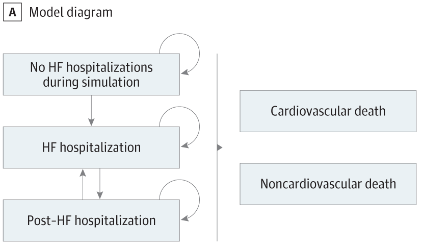

*Figure 1A. Published model schematic.* Simulated health states and transitions in the source analysis. Panel A of Figure 1 of Cohen et al. (2023), [doi:10.1001/jamacardio.2023.0077](https://doi.org/10.1001/jamacardio.2023.0077), © American Medical Association.

Source: Cohen LP, Isaza N, Hernandez I, et al. Cost-effectiveness of sodium-glucose cotransporter-2 inhibitors for the treatment of heart failure with preserved ejection fraction. *JAMA Cardiol.* 2023;8(5):419-428. [doi:10.1001/jamacardio.2023.0077](https://doi.org/10.1001/jamacardio.2023.0077). Figure 1 (“Model Schematic and Mortality Projections”), panel A. Original legend: “A, Simulated health states and transitions…” © 2023 American Medical Association. All rights reserved.

# 1 Setup

Load packages and set the number of probabilistic sensitivity analysis (PSA) iterations. 1,000 probabilistic iterations were used.

```r
library("hesim")
library("data.table")
library("kableExtra")
library("flexsurv")
library("ggplot2")
library(flow) #Code Flow Diagrams
n_samples <- 1000

# Shared definitions.
source("R/helpers.R", local = knitr::knit_global())
source("R/model.R",   local = knitr::knit_global())
```

# 2 Model overview

*[Individual-level state-transition model](https://hesim-dev.github.io/hesim/articles/mstate.html)* of HFpEF in [`hesim`](https://hesim-dev.github.io/hesim/)<sup>1</sup> after Cohen et al.<sup>2</sup> “The paper” always means that single source, cited in full at the top of the reproduction document. Nine numbered transitions connect these states (see the transition matrix below). Living-state names in `hesim` are short labels. SGLT2i versus SoC, cohort matched to EMPEROR-Preserved<sup>3</sup> and DELIVER<sup>4</sup>.

# 3 Parameters

## 3.1 Transition structure

In an individual patient simulation, possible transitions are encoded in a matrix.

```r
tmat <- rbind(
  c(NA,  1,  NA,  2,  3),
  c(NA, NA,   4,  5,  6),
  c(NA,  7,  NA,  8,  9),
  c(NA, NA,  NA, NA, NA),
  c(NA, NA,  NA, NA, NA)
)
colnames(tmat) <- rownames(tmat) <- c("Stable", "HF Hospitalization",
                                       "Post-HF Hospitalization",
                                       "CV Death", "Non-CV Death")

# Display the matrix
tmat %>%
  kable(align = "c") %>%
  kable_styling()
```

|  | Stable | HF Hospitalization | Post-HF Hospitalization | CV Death | Non-CV Death |
| --- | --- | --- | --- | --- | --- |
| Stable | NA | 1 | NA | 2 | 3 |
| HF Hospitalization | NA | NA | 4 | 5 | 6 |
| Post-HF Hospitalization | NA | 7 | NA | 8 | 9 |
| CV Death | NA | NA | NA | NA | NA |
| Non-CV Death | NA | NA | NA | NA | NA |

Progression, CV death, non-CV death: *1-3* from Stable (first HF hospitalization), *4-6* from HF hospitalization, *7-9* from post-HF hospitalization; death states are all absorbing.

## 3.2 Strategies, patients, and hesim data objects

Three `hesim` building blocks: strategies, patients, three living cost/utility states; death in the transition matrix.

```r
strategies <- data.table(
  strategy_id = 1:2,
  strategy_name = c("SOC", "SGLT2i")
)
n_strategies <- nrow(strategies)

n_patients <- 3000
patients <- data.table(
  patient_id = 1:n_patients,
  gender = sample(c("Male", "Female"), n_patients, replace = TRUE, prob = c(0.557, 0.443)),
  age = pmin(round(rnorm(n_patients, mean = 71.7, sd = 9.5)), 115)  # cap < max_age (120)
)
```

Living states:

```r
states <- data.table(
  state_id   = 1:3,
  state_name = c("Stable", "HF Hospitalization", "Post-HF Hospitalization")
)
n_states <- nrow(states)   # = 3
```

Bundle strategies, patients, and states into a single `hesim_data` object:

```r
hesim_dat <- hesim_data(strategies = strategies,
                        patients = patients,
                        states = states)
print(hesim_dat)
```

```
## $strategies
##    strategy_id strategy_name
##          <int>        <char>
## 1:           1           SOC
## 2:           2        SGLT2i
##
## $patients
##       patient_id gender   age
##            <int> <char> <num>
##    1:          1   Male    74
##    2:          2 Female    78
##    3:          3 Female    58
##    4:          4   Male    60
##    5:          5 Female    68
##   ---
## 2996:       2996 Female    79
## 2997:       2997 Female    82
## 2998:       2998 Female    80
## 2999:       2999   Male    80
## 3000:       3000   Male    66
##
## $states
##    state_id              state_name
##       <int>                  <char>
## 1:        1                  Stable
## 2:        2      HF Hospitalization
## 3:        3 Post-HF Hospitalization
##
## attr(,"class")
## [1] "hesim_data"
```

`get_labels()` builds human-readable labels for tables and plots later in the document:

```r
hesim_labs <- get_labels(hesim_dat)
print(hesim_labs)
```

```
## $strategy_id
##    SOC SGLT2i
##      1      2
##
## $state_id
##                  Stable      HF Hospitalization Post-HF Hospitalization
##                       1                       2                       3
##                   Death
##                       4
```

## 3.3 Key literature inputs

Base-case model inputs; full Table 1 follows the utility and cost definitions. Rates are *per person-year* unless noted.

Key literature inputs for the multi-state model (base case). Source is the primary reference, else the paper’s Table 1.

| Parameter | Base case | Source |
| --- | --- | --- |
| First HF hospitalization rate | 0.0626 | Anker et al.<sup>3</sup>; Solomon et al.<sup>4</sup> |
| HF-hosp HR (SGLT2i vs SoC) | 0.74 | Vaduganathan et al.<sup>5</sup> |
| CV-death rate (in-trial) | 0.0356 | Anker et al.<sup>3</sup>; Solomon et al.<sup>4</sup> |
| CV-death HR | 0.88 | Vaduganathan et al.<sup>5</sup> |
| All-cause death rate (in-trial) | 0.0716 | Anker et al.<sup>3</sup>; Solomon et al.<sup>4</sup> |
| Non-CV death RR (in-trial) | 1.05 | Cohen et al.<sup>2</sup> |
| 30-day any-cause readmission | 21.27% | Cheng et al.<sup>6</sup>; Arora et al.<sup>7</sup>; Goyal et al.<sup>8</sup> |
| Rehospitalization RR, 2–6 mo | 0.34 | Chamberlain et al.<sup>9</sup> |
| Rehospitalization RR, 7–12 mo | 0.21 | Chamberlain et al.<sup>9</sup> |
| Rehospitalization RR, 13–24 mo | 0.18 | Chamberlain et al.<sup>9</sup> |
| PSA iterations | 1,000 | – |

Trial enrollment (N = 12,251 pooled) informs population characteristics.<sup>3,4</sup>

## 3.4 Transition-specific parameters

Each transition gets base rates or fixed times and, where relevant, SGLT2i effects, re-collected later for the PSA.

### 3.4.1 Transition 1: Stable → HF hospitalization

First HF hospitalization rates (6.26 per 100 person-years) are pooled from EMPEROR-Preserved<sup>3</sup> and DELIVER<sup>4</sup>. SGLT2i hazard ratio (0.74) was implemented from the trial meta-analysis.<sup>5</sup> In the full PSA these are drawn lognormally from Table 1 ranges; placeholders below are the point estimates.

```r
rateFirstHFhosp <- 0.0626
hrHFhosp_sglt2i <- 0.74
```

### 3.4.2 Transition 2: Stable → CV death

In-trial CV death rate; lifetime SGLT2i HR 0.88.<sup>5</sup> Post-trial: age-scaled hazard.

```r
rateCVdeath <- 0.0356  # 3.56 per 100 person-years
hrCVdeath_sglt2i <- 0.88
```

### 3.4.3 Transition 3: Stable → non-CV death

Non-CV mortality: *all-cause minus CV* (eMethods 2); RR 1.05 in-trial.

```r
rateAllCauseDeath <- 0.0716  # 7.16 per 100 person-years
rateCVdeath <- 0.0356        # 3.56 per 100 person-years

rateNonCVdeath <- rateAllCauseDeath - rateCVdeath  # = 0.0360 per person-year, Refer to eMethods 2, Step 7
rrNonCVdeath_sglt2i_intrial <- 1.05
```

### 3.4.4 Transition 4: HF hospitalization → post-HF hospitalization (discharge)

Length of stay is fixed at *7 days* for every admission (no treatment effect on stay duration).

### 3.4.5 Transition 5: HF hospitalization → CV death

Age-stratified in Table 1: fatal HF hospitalization 3.30% (3.14-3.46) if <75 y, 5.10% (4.99-5.21) if >=75 y; both beta.

Probabilities convert to rates over the 7-day stay via `prob_to_rate()`.

In-hospital death is later replaced by the background CV hazard; transition 5 is passed `cv_pwexp` in `params_surv_list()`.

```r
probInHospCVdeath_under75_shape1 <- 3.3
probInHospCVdeath_under75_shape2 <- 96.7
probInHospCVdeath_over75_shape1 <- 5.1
probInHospCVdeath_over75_shape2 <- 94.9
```

### 3.4.6 Transition 6: HF hospitalization → non-CV death

Same structure as transition 5 for non-cardiovascular in-hospital death (shape parameters from Table 1).

```r
probInHospNonCVdeath_shape1 <- 3.37
probInHospNonCVdeath_shape2 <- 96.63
```

### 3.4.7 Transition 7: Post-HF hospitalization → HF rehospitalization

30-day readmission 21.27% any-cause,<sup>6–8</sup> 48.21% HF-related,<sup>10</sup> later RRs 0.34/0.21/0.18;<sup>9</sup> Table 1.

```r
prob30d_readmit <- 0.2127
propHF_readmit <- 0.4821
rr_rehosp_2to6mo <- 0.34
rr_rehosp_7to12mo <- 0.21
rr_rehosp_13to24mo <- 0.18
rehosp_times <- c(0, 30/365, 6/12, 12/12)   # 4 pwexp knots matching rr_rehosp segments
```

### 3.4.8 Transition 8: Post-HF hospitalization → CV death

Same in-trial CV death rate and SGLT2i HR as transition 2 (background mortality after discharge).

```r
rateCVdeath_postHF <- 0.0356
hrCVdeath_sglt2i <- 0.88
```

### 3.4.9 Transition 9: Post-HF hospitalization → non-CV death

Same non-CV rate and in-trial RR as transition 3.

```r
rateNonCVdeath_postHF <- 0.0360
rrNonCVdeath_sglt2i_intrial <- 1.05
```

## 3.5 Multi-state model assembly

### 3.5.1 Collect rates and PSA knobs

Bring transition-level scalars into one place for the multi-state survival models. *`n_samples = 1000`* is the PSA size used for all probabilistic results in Table 2 and more.

```r
# Rates
rateFirstHFhosp <- 0.0626
rateCVdeath <- 0.0356
rateNonCVdeath <- 0.0360
rateCVdeath_postHF <- 0.0356
rateNonCVdeath_postHF <- 0.0360

# Fixed time
ttrDischarge <- 7/365

# Beta shape parameters
probInHospCVdeath_shape1 <- 4.2
probInHospCVdeath_shape2 <- 95.8
probInHospNonCVdeath_shape1 <- 3.37
probInHospNonCVdeath_shape2 <- 96.63
prob30d_readmit_shape1 <- 21.27
prob30d_readmit_shape2 <- 78.73
propHF_readmit <- 0.4821

# Piecewise RRs and times
rr_rehosp <- c(1.00, 0.34, 0.21, 0.18)
rehosp_times <- c(0, 30/365, 6/12, 12/12)

# PSA iterations
n_samples <- 1000  # PSA iterations (paper: 1,000)
```

### 3.5.2 Helper functions

`prob_to_rate()` converts a probability to a constant rate; `vec_to_dt()` builds the one-column `cons` table `hesim` expects.

```r
# Probability over interval t -> equivalent constant rate.
prob_to_rate <- function(p, t = 1) {
  (-log(1 - p)) / t
}

# 95% range -> lognormal SD on the log scale.
sdlog <- function(low, high) (log(high) - log(low)) / (2 * qnorm(0.975))
```

```r
# Scalars recycle to global n_samples.
vec_to_dt <- function(v, n = NULL){
  if (length(v) == 1) v <- rep(v, n_samples)
  dt <- data.table(v)
  colnames(dt) <- "cons"
  return(dt)
}

# Matrix or data.table of piecewise log-rates -> list of one-column coef tables.
as_dt_list <- function(x){
  x <- as.data.table(as.matrix(x))   # handles matrix or data.table input
  lapply(x, vec_to_dt)
}
```

Both are read from `R/helpers.R`, sourced in Setup, so they cannot drift; full contents of both shared files below.

### 3.5.3 US life tables and CV fraction of deaths

Sex-blended life-table hazards<sup>11</sup> give slope $b$ (Equation 1); CDC WONDER<sup>12</sup> sets CV-split shape, not level (eMethods 2).

$$\begin{aligned}
\textbf{(1)}\quad m_x^{(g)} &= -\log\!\bigl(1 - q_x^{(g)}\bigr),
&& g \in \{\text{male},\, \text{female}\},\quad x = 60, \dots,
99 \\[4pt]
\textbf{(2)}\quad m_x &= 0.557\, m_x^{(\text{male})} + 0.443\,
m_x^{(\text{female})}
&& \\[4pt]
\textbf{(3)}\quad \log m_x &= a + b\,x + \varepsilon_x,
&& x \geq 72 \quad\Longrightarrow\quad \hat{b} = 0.110\
\text{y}^{-1}
\end{aligned}$$

*Equation 1. Life-table $q_x$ to the post-trial mortality slope* ($R^2 = 0.999$). Only $\hat{b}$ carries forward: slope, not level.

### 3.5.4 Piecewise mortality gradient (in-trial flat, then age-rising)

$$\begin{aligned}
g(a) &= \begin{cases}
1, & a \leq \text{trial end (2.3 y)}\\[2pt]
k_{\text{calib}}\, e^{\,b\,(a-\text{anchor})}, & a >
\text{trial end}
\end{cases}
&\qquad
s_{\text{cv}}(a) &=
\min\!\Bigl(\tfrac{4.73}{3.54}\,\text{cv\_frac}(a),\; 0.95\Bigr)\\[6pt]
g_{\text{cv}}(a) &=
g(a)\,\frac{\lambda_{\text{cv}}+\lambda_{\text{ncv}}}{\lambda_{\text{cv}}}\;s_{\text{cv}}(a)
&\qquad
g_{\text{ncv}}(a) &=
g(a)\,\frac{\lambda_{\text{cv}}+\lambda_{\text{ncv}}}{\lambda_{\text{ncv}}}\;\bigl(1-s_{\text{cv}}(a)\bigr)
\end{aligned}$$

*Equation 3. Post-trial gradient; `k_calib` tuned to 7.73 y.*<sup>11,12</sup> (eMethods 2)

```r
baseline_age <- 72     # cohort mean 71.7
trial_end    <- 2.3
anchor_age   <- 73
k_calib      <- 0.94

rate_cv_intrial    <- 0.0356
rate_noncv_intrial <- 0.0360
hr_cv            <- 0.88
rr_ncv_intrial   <- 1.05   # all-cause HR ≈ 0.97
rr_ncv_posttrial <- 1.00

seg_starts <- seq(trial_end, 32.3, by = 5)
seg_times  <- c(0, seg_starts)              # 0, 2.3, 7.3, ... 32.3
mid_age    <- baseline_age + seg_starts + 2.5
# Cause split (eMethods 2): s_cv = (RR_cv/RR_all)*cv_frac(age); total hazard unchanged
xwalk_cv <- 4.73 / 3.54                     # RR_cv / RR_all
lvl_cv   <- rate_cv_intrial
lvl_ncv  <- rate_noncv_intrial

gradients      <- mortality_gradients()     # R/model.R; build_sens() calls the same function
cv_gradient    <- gradients$cv
noncv_gradient <- gradients$ncv
n_seg          <- length(cv_gradient)
```

### 3.5.5 Sample transition coefficients for the PSA

`define_rng()` samples beta transition probabilities; treatment HRs are drawn lognormally.

```r
# PSA RNG: beta (in-hosp death, 30-d readmit), fixed rates, piecewise rehosp
transmod_coef_def <- define_rng({

  # In-hospital CV death probability → rate over LOS
  probInHospCVdeath <- beta_rng(shape1 = probInHospCVdeath_shape1,
                                 shape2 = probInHospCVdeath_shape2)
  rateInHospCVdeath <- prob_to_rate(probInHospCVdeath, t = ttrDischarge)

  # In-hospital non-CV death probability → rate over LOS
  probInHospNonCVdeath <- beta_rng(shape1 = probInHospNonCVdeath_shape1,
                                    shape2 = probInHospNonCVdeath_shape2)
  rateInHospNonCVdeath <- prob_to_rate(probInHospNonCVdeath, t = ttrDischarge)

  # 30-day any-cause readmission → HF-related rate
  prob30d_readmit <- beta_rng(shape1 = prob30d_readmit_shape1,
                               shape2 = prob30d_readmit_shape2)
  prob30d_HFreadmit <- prob30d_readmit * propHF_readmit
  rate30d_HFreadmit <- prob_to_rate(prob30d_HFreadmit, t = 30/365)

  # Placeholder rates (levels re-drawn or re-scaled later where needed)
  rate1 <- fixed(rateFirstHFhosp)       # Stable → HF hosp
  rate2 <- fixed(rateCVdeath)           # Stable → CV death
  rate3 <- fixed(rateNonCVdeath)        # Stable → non-CV death
  rate8 <- fixed(rateCVdeath_postHF)    # Post-HF → CV death
  rate9 <- fixed(rateNonCVdeath_postHF) # Post-HF → non-CV death

  # Rehospitalization: base 30-d HF rate × piecewise RRs
  rehosp <- cbind(rate30d_HFreadmit * rr_rehosp[1],
                  rate30d_HFreadmit * rr_rehosp[2],
                  rate30d_HFreadmit * rr_rehosp[3],
                  rate30d_HFreadmit * rr_rehosp[4])
  colnames(rehosp) <- paste0("time_", rehosp_times)
  # Coefficients on log scale (except fixed discharge time)
  list(
    log_rate1 = vec_to_dt(log(rate1)),   # 1 Stable → HF hosp
    log_rate2 = vec_to_dt(log(rate2)),   # 2 Stable → CV death
    log_rate3 = vec_to_dt(log(rate3)),   # 3 Stable → non-CV death
    ttr4 = vec_to_dt(ttrDischarge),      # 4 HF hosp → post-HF (fixed)
    log_rate5 = vec_to_dt(log(rateInHospCVdeath)),    # 5
    log_rate6 = vec_to_dt(log(rateInHospNonCVdeath)), # 6
    log_rehosp = log(rehosp),            # 7 Post-HF → HF hosp (pwexp)
    log_rate8 = vec_to_dt(log(rate8)),   # 8 Post-HF → CV death
    log_rate9 = vec_to_dt(log(rate9))    # 9 Post-HF → non-CV death
  )
}, n = n_samples)

transmod_coef <- eval_rng(transmod_coef_def)
```

Draw the first HF hospitalization rate, its treatment hazard ratio, and the CV-death hazard ratio lognormally. The rate replaces its placeholder; the hazard ratios enter as `sglt2i` columns on the transitions that apply them directly:

```r
# One draw per sample, reused wherever that HR applies
set.seed(101)

rate1_draws  <- rlnorm(n_samples, log(rateFirstHFhosp), sdlog(0.0589, 0.0671)) # 6.26 (5.89-6.71)
hr_hfhosp_dr <- rlnorm(n_samples, log(hrHFhosp_sglt2i), sdlog(0.67, 0.83))     # 0.74 (0.67-0.83)
hr_cv_dr     <- rlnorm(n_samples, log(hrCVdeath_sglt2i), sdlog(0.77, 1.00))    # 0.88 (0.77-1.00)

# SGLT2i log columns
transmod_coef$log_rate1[, cons   := log(rate1_draws)]
transmod_coef$log_rate1[, sglt2i := log(hr_hfhosp_dr)]   # HF-hosp HR (trans 1)
transmod_coef$log_rate5[, sglt2i := log(hr_cv_dr)]       # CV-death HR (trans 5)
transmod_coef$log_rate6[, sglt2i := log(rrNonCVdeath_sglt2i_intrial)]  # non-CV RR fixed (no range)
```

Summarize the coefficient list:

```r
summary(transmod_coef)
```

```
##                                  param        mean         sd        2.5%
##                                 <char>       <num>      <num>       <num>
##  1:                     log_rate1_cons -2.77214921 0.03189176 -2.83194443
##  2:                   log_rate1_sglt2i -0.30195255 0.05689339 -0.41681781
##  3:                     log_rate2_cons -3.33540964 0.00000000 -3.33540964
##  4:                     log_rate3_cons -3.32423634 0.00000000 -3.32423634
##  5:                          ttr4_cons  0.01917808 0.00000000  0.01917808
##  6:                     log_rate5_cons  0.67057168 0.53016594 -0.53222411
##  7:                   log_rate5_sglt2i -0.12288300 0.06480032 -0.24756038
##  8:                     log_rate6_cons  0.42985411 0.60823578 -0.95498472
##  9:                   log_rate6_sglt2i  0.04879016 0.00000000  0.04879016
## 10:                  log_rehosp_time_0  0.25449577 0.20567610 -0.18381022
## 11: log_rehosp_time_0.0821917808219178 -0.82431389 0.20567610 -1.26261988
## 12:                log_rehosp_time_0.5 -1.30615198 0.20567610 -1.74445797
## 13:                  log_rehosp_time_1 -1.46030266 0.20567610 -1.89860865
```

[output cut: 19 more lines]

Inspect a few sampled tables (fixed discharge time; transition-1 log-rates with `cons` and `sglt2i`):

```r
head(transmod_coef$ttr4)
```

```
##          cons
##         <num>
## 1: 0.01917808
## 2: 0.01917808
## 3: 0.01917808
## 4: 0.01917808
## 5: 0.01917808
## 6: 0.01917808
```

```r
head(transmod_coef$log_rate1)
```

```
##         cons     sglt2i
##        <num>      <num>
## 1: -2.781831 -0.2736152
## 2: -2.752620 -0.4156912
## 3: -2.793433 -0.3062668
## 4: -2.763862 -0.2456800
## 5: -2.760657 -0.3054428
## 6: -2.731954 -0.3150429
```

### 3.5.6 Survival distributions for all nine transitions

Transitions need a distribution, coefficients, and (pwexp only) knot times: nine `params_surv()` in a `params_surv_list()`.

The chunk below:

It builds *piecewise-exponential CV/non-CV death* models with post-trial gradients, gives transitions 1-9 [*exp / fixed / pwexp*](https://hesim-dev.github.io/hesim/reference/params_surv.html) forms, keeps *background* hazards in hospital, and applies the *HF-hosp HR to readmissions* and first hospitalizations.

```r
# as_dt_list() is defined in R/helpers.R.

set.seed(1)
cv_draws    <- rlnorm(n_samples, log(rate_cv_intrial),    0.046)   # in-trial LEVEL, PSA
noncv_draws <- rlnorm(n_samples, log(rate_noncv_intrial), 0.046)

# Base case: CV-death HR for life.
cv_pwexp    <- make_death_pwexp(cv_draws, cv_gradient, rep(list(log(hr_cv_dr)), n_seg))
noncv_pwexp <- make_death_pwexp(noncv_draws, noncv_gradient,
                  c(list(log(rr_ncv_intrial)),
                    rep(list(log(rr_ncv_posttrial)), n_seg - 1)))

transmod_params <- params_surv_list(
  params_surv(coefs = list(rate = transmod_coef$log_rate1), dist = "exp"),        # 1
  params_surv(coefs = cv_pwexp,    aux = list(time = seg_times), dist = "pwexp"), # 2
  params_surv(coefs = noncv_pwexp, aux = list(time = seg_times), dist = "pwexp"), # 3
  params_surv(coefs = list(est = transmod_coef$ttr4), dist = "fixed"),            # 4
  # Trans 5–6: background CV/non-CV hazard in HF-hosp (no double-counted in-hosp death)
  params_surv(coefs = cv_pwexp,    aux = list(time = seg_times), dist = "pwexp"), # 5
  params_surv(coefs = noncv_pwexp, aux = list(time = seg_times), dist = "pwexp"), # 6
  # Trans 7: same HF-hosp HR on readmissions as on first hosp (aligned with hr_hfhosp_dr)
  params_surv(coefs = lapply(as_dt_list(transmod_coef$log_rehosp),
                             function(seg) seg[, sglt2i := log(hr_hfhosp_dr)][]),
              aux = list(time = rehosp_times), dist = "pwexp"),                    # 7
  params_surv(coefs = cv_pwexp,    aux = list(time = seg_times), dist = "pwexp"), # 8
  params_surv(coefs = noncv_pwexp, aux = list(time = seg_times), dist = "pwexp")  # 9
)
```

Rehospitalization knot count should match the number of piecewise coefficient columns.

```r
length(rehosp_times)
```

```
## [1] 4
```

```r
ncol(transmod_coef$log_rehosp)
```

```
## [1] 4
```

```r
colnames(transmod_coef$log_rehosp)
```

```
## [1] "time_0"                  "time_0.0821917808219178"
## [3] "time_0.5"                "time_1"
```

## 3.6 Utility and costs

### 3.6.1 Health-related quality of life

Utilities follow eMethods 4 and Table 1: baseline 0.783, SGLT2i +0.0084.

```r
# Table 1 utility; SE from 95% range
se_baseline <- (0.7859 - 0.7802) / (2 * 1.96)   # ≈ 0.00145
utility_baseline    <- 0.783
sglt2i_utility_gain <- 0.0084

disutility_hosp <- 0.16
age_util_slope  <- 0.0007

u_base <- rbeta(n_samples,
                utility_baseline * (utility_baseline*(1-utility_baseline)/se_baseline^2 - 1),
                (1-utility_baseline) * (utility_baseline*(1-utility_baseline)/se_baseline^2 - 1))
u_gain <- rnorm(n_samples, 0.0084, (0.0128 - 0.0040)/(2*1.96))   # Table 1 range

# No urgent-care state (-0.054 gap).
u_years <- 0:40
utility_tbl <- stateval_tbl(
  CJ(sample = 1:n_samples, strategy_id = strategies$strategy_id,
     state_id = states$state_id, time_start = u_years)[
    , `:=`(
        ub   = u_base[sample],
        gain = fifelse(strategy_id == 2L, u_gain[sample], 0),
        adec = fifelse(time_start >= 1, age_util_slope * (time_start - 1 + 0.5), 0),
        hdec = fifelse(state_id == 2L & time_start >= 1, disutility_hosp, 0))][
    , value := ub - adec - hdec + gain][
    , .(sample, strategy_id, state_id, time_start, value)],
  dist = "custom"
)
```

### 3.6.2 Drug costs

*Validation anchor.* The pooled 2022 FSS Big-4 price of $4,506,<sup>13</sup> less 18.62% discontinuation, gives $3,667 net annual drug cost in Stable and Post-HF, SGLT2i arm only. 2026 prices are defined here for the Figure 4 headline.

*2026 prices.*<sup>14</sup> Big-4 ceiling, 10 mg monthly: empagliflozin $313.42; brand dapagliflozin $444.96; generic $241.54.

```r
sglt2i_annual_cost <- 4506       # 2022 pooled FSS (validation anchor)
discontinuation_rate <- 0.1862   # 2022 pooled discontinuation
sglt2i_adjusted_cost <- sglt2i_annual_cost * (1 - discontinuation_rate)  # = $3667

# 2026 FSS Big-4, 10 mg daily, 30-tab bottle x 12 (VA OPAL/NAC file, 2026-03-01; ref 6)
price_empa       <- 313.42 * 12   # $3,761  JARDIANCE, NDC 00597-0152-30
price_dapa_brand <- 444.96 * 12   # $5,340  FARXIGA,   NDC 00310-6210-30
price_dapa_gen   <- 241.54 * 12   # $2,898  dapagliflozin generic (Prasco), NDC 66993-0457-30

drugcost_tbl <- stateval_tbl(
  data.table(
    strategy_id = rep(strategies$strategy_id, each = n_states),
    state_id    = rep(states$state_id, times = n_strategies),
    est = c(
      0, 0, 0,                                      # SoC: no drug cost
      sglt2i_adjusted_cost, 0, sglt2i_adjusted_cost # SGLT2i: Stable + Post-HF
    )
  ),
  dist = "fixed"
)

head(drugcost_tbl)
```

```
##    strategy_id state_id      est
##          <int>    <int>    <num>
## 1:           1        1    0.000
## 2:           1        2    0.000
## 3:           1        3    0.000
## 4:           2        1 3666.983
## 5:           2        2    0.000
## 6:           2        3 3666.983
```

### 3.6.3 Medical costs

*Background medical costs* are annual rates by age band,<sup>15</sup> applied by length of stay; with mean start age about 72, bands switch at model years 0, 3, and 13. The model adds *$12,528 per admission* on *entry* to the HF-hospitalization state.<sup>16</sup>

```r
background_cost_bands <- data.table(
  time_start = c(0, 3, 13),
  mean = c(23004, 23871, 32998),
  se   = c((23789 - 22217) / (2 * 1.96),    # age <75
           (24454 - 23288) / (2 * 1.96),    # age 75-84
           (33765 - 32231) / (2 * 1.96))    # age >=85
)
background_cost_annual <- background_cost_bands$mean[1]
background_cost_se     <- background_cost_bands$se[1]

hf_hosp_cost <- 12528

medcost_tbl <- stateval_tbl(
  data.table(
    state_id   = rep(states$state_id, each = nrow(background_cost_bands)),
    time_start = rep(background_cost_bands$time_start, times = n_states),
    mean       = rep(background_cost_bands$mean, times = n_states),
    se         = rep(background_cost_bands$se,   times = n_states)
  ),
  dist = "gamma"
)

# Per admission; method = "starting" is set below (wlos would understate it ~50x)
hfhospcost_tbl <- stateval_tbl(
  data.table(
    state_id = states$state_id,
    est = c(0, hf_hosp_cost, 0)
  ),
  dist = "fixed"
)

head(medcost_tbl)
```

```
##    state_id time_id time_start time_stop  mean       se
##       <int>   <int>      <num>     <num> <num>    <num>
## 1:        1       1          0         3 23004 401.0204
## 2:        1       2          3        13 23871 297.4490
## 3:        1       3         13       Inf 32998 391.3265
## 4:        2       1          0         3 23004 401.0204
## 5:        2       2          3        13 23871 297.4490
## 6:        2       3         13       Inf 32998 391.3265
```

```r
head(hfhospcost_tbl)
```

```
##    state_id   est
##       <int> <num>
## 1:        1     0
## 2:        2 12528
## 3:        3     0
```

# 4 Table 1. Model inputs

This table mirrors the paper’s Table 1; “In model?” flags each input as implemented, approximated, or a structural gap.

Table 1. Model inputs (Cohen et al. 2023). ‘In model?’ flags implementation here; Source is the paper’s attribution.

[output not shown]

# 5 Simulation

## 5.1 Constructing the model

The economic model combines a multi-state *disease* model, a *utility* model, and *cost* models in one `IndivCtstm` object.

### 5.1.1 Disease model input data

`expand()` builds one row per treatment strategy × patient. That table is the input data for the continuous-time transition model.

```r
transmod_data <- expand(hesim_dat, by = c("strategies", "patients"))
head(transmod_data)
```

```
##    strategy_id patient_id strategy_name gender   age
##          <int>      <int>        <char> <char> <num>
## 1:           1          1           SOC   Male    74
## 2:           1          2           SOC Female    78
## 3:           1          3           SOC Female    58
## 4:           1          4           SOC   Male    60
## 5:           1          5           SOC Female    68
## 6:           1          6           SOC   Male    75
```

Covariate columns for the survival linear predictors: `sglt2i` carries the treatment effect, `cons` the intercept.

```r
transmod_data[, cons := 1]
transmod_data[, male := ifelse(gender == "Male", 1, 0)]
transmod_data[, sglt2i := ifelse(strategy_name == "SGLT2i", 1, 0)]
```

`clock = "forward"`: time from simulation start, not state entry; `start_age` sets the age cap.

```r
transmod <- create_IndivCtstmTrans(transmod_params,
                                   input_data = transmod_data,
                                   trans_mat = tmat,
                                   clock = "forward",
                                   start_age = patients$age)
```

### 5.1.2 Cost and utility models

Utility and cost `StateVals` objects are built from the tables defined earlier. Background medical cost uses the default length-of-stay weighting; HF hospitalization cost uses `method = "starting"` so the event cost fires once per admission.

```r
# Utility
utilitymod <- create_StateVals(utility_tbl,
                               n = n_samples,
                               hesim_data = hesim_dat)

# Costs
drugcostmod <- create_StateVals(drugcost_tbl,
                                n = n_samples,
                                hesim_data = hesim_dat)

medcostmod <- create_StateVals(medcost_tbl,
                               n = n_samples,
                               hesim_data = hesim_dat)

hfhospcostmod <- create_StateVals(hfhospcost_tbl,
                                  n = n_samples,
                                  hesim_data = hesim_dat,
                                  method = "starting")

costmods <- list(Drug = drugcostmod,
                 Medical = medcostmod,
                 HFhosp = hfhospcostmod)
```

### 5.1.3 Combining the models

Combine disease, utility, and cost models into a single economic model object:

```r
econmod <- IndivCtstm$new(trans_model = transmod,
                          utility_model = utilitymod,
                          cost_models = costmods)
```

## 5.2 Shared code

Both documents source the same two R utility files; the listings below are read from them and cannot drift.

### 5.2.1 `R/helpers.R`

Converts a published probability to a constant rate over its interval, and a 95% range to the PSA lognormal SD.

```r
# Probability over interval t -> equivalent constant rate.
prob_to_rate <- function(p, t = 1) {
  (-log(1 - p)) / t
}

# 95% range -> lognormal SD on the log scale.
sdlog <- function(low, high) (log(high) - log(low)) / (2 * qnorm(0.975))
```

`hesim` expects intercept-only survival coefficients as a one-column `cons` table; these build one from a scalar, a vector, or a matrix of piecewise log-rates.

```r
# Scalars recycle to global n_samples.
vec_to_dt <- function(v, n = NULL){
  if (length(v) == 1) v <- rep(v, n_samples)
  dt <- data.table(v)
  colnames(dt) <- "cons"
  return(dt)
}

# Matrix or data.table of piecewise log-rates -> list of one-column coef tables.
as_dt_list <- function(x){
  x <- as.data.table(as.matrix(x))   # handles matrix or data.table input
  lapply(x, vec_to_dt)
}
```

Builds the per-segment tables for a piecewise-exponential death transition: a log baseline rate scaled by the mortality gradient, plus the treatment log-HR.

```r
# Per-segment coef tables (cons + sglt2i log-HR) for a pwexp death model.
make_death_pwexp <- function(level, gradient, seg_loghr) {
  lapply(seq_along(gradient), function(i) {
    lh <- seg_loghr[[i]]
    data.table(cons   = log(level * gradient[i]),
               sglt2i = if (length(lh) == 1) rep(lh, length(level)) else lh)
  })
}
```

Both documents report probabilistic results as *mean (2.5th to 97.5th percentile)* across PSA samples, at two decimals, three decimals, or whole dollars.

```r
# Mean (2.5th to 97.5th pct) across PSA samples: 2 dp, 3 dp, money.
ui  <- function(x) sprintf("%.2f (%.2f to %.2f)", mean(x), quantile(x, .025), quantile(x, .975))
ui3 <- function(x) sprintf("%.3f (%.3f to %.3f)", mean(x), quantile(x, .025), quantile(x, .975))
uiM <- function(x) sprintf("%s (%s to %s)", format(round(mean(x)), big.mark = ","),
                           format(round(quantile(x, .025)), big.mark = ","),
                           format(round(quantile(x, .975)), big.mark = ","))
```

Fills eTables 7 and 11 with the ACC/AHA value colours the published eTable 7 uses; non-finite ICERs fall through to white rather than becoming `NA`.

```r
# ACC/AHA value bands, paper eTable 7.
value_bg <- function(x) {
  x   <- as.numeric(x)
  out <- rep("#FFFFFF", length(x))
  ok  <- is.finite(x)
  out[ok & x < 150000] <- "#FFF2CC"
  out[ok & x <  50000] <- "#D9EAD3"
  out
}
```

### 5.2.2 `R/model.R`

#### 5.2.2.1 `mortality_gradients()`

eMethods 2, computed in one place only: the PSA and every deterministic scenario call this function, so the two cannot drift apart.

```r
# eMethods 2. Single source of truth.
mortality_gradients <- function(kcal = k_calib) {
  grad_all <- kcal * exp(b * (mid_age - anchor_age))
  lvl_all  <- lvl_cv + lvl_ncv
  s_cv     <- pmin(xwalk_cv * cv_frac(mid_age), 0.95)
  list(cv  = c(1.0, grad_all * (lvl_all / lvl_cv)  * s_cv),
       ncv = c(1.0, grad_all * (lvl_all / lvl_ncv) * (1 - s_cv)))
}
```

#### 5.2.2.2 `build_sens()`

Rebuilds the model at mean parameter values with any input overridden through `ovr`. It opens by drawing the cohort and the `hesim` data container.

```r
build_sens <- function(ovr = list(), np = 6000, kcal = k_calib) {
  g <- function(nm, d) if (!is.null(ovr[[nm]])) ovr[[nm]] else d
  set.seed(42)
  abase <- g("base_age", 71.7)
  pats <- data.table(patient_id = 1:np,
    gender = sample(c("Male", "Female"), np, TRUE, c(0.557, 0.443)),
    age = pmin(round(rnorm(np, abase, 9.5)), 115))  # cap < max_age
  sts <- data.table(state_id = 1:3, state_name = states$state_name)
  hd  <- hesim_data(strategies = strategies, patients = pats, states = sts)
  vdt <- function(v) { v <- rep(v, 1); dt <- data.table(v); setnames(dt, "cons"); dt }
```

Segment grid and gradient come from the shared function above; then the rates and hazard ratios a scenario is allowed to override.

```r
  segT     <- seg_times
  grads    <- mortality_gradients(kcal)
  grad_cv  <- grads$cv
  grad_ncv <- grads$ncv
  nseg <- length(grad_cv)
  r1 <- g("rateFirstHFhosp", rateFirstHFhosp); hrHF <- g("hr_hfhosp", hrHFhosp_sglt2i); hrCV <- g("hr_cv", hrCVdeath_sglt2i)
  nrr  <- g("noncv_rr", rr_ncv_intrial)        # in-trial non-CV RR (1 = no mortality effect)
  npo  <- g("noncv_rr_post", rr_ncv_posttrial) # post-trial non-CV RR (1.05 = effect persists)
```

eTable 8’s waning scenarios ramp the treatment effect linearly to nothing over the five years after trial end; `wsegT` is each segment’s mean of that ramp.

```r
  te <- trial_end; wend <- te + 5                    # trial end; effect gone by 7.3 y
  wane <- isTRUE(g("hr_wane_5y", FALSE))             # HF-hosp + CV-death HRs
  qw   <- isTRUE(g("qol_wane_5y", FALSE))            # utility gain
  wsegT   <- c(1, 0.5, rep(0, nseg - 2))             # segment means of the linear ramp
  hrHFseg <- if (wane) log(hrHF) * wsegT else rep(log(hrHF), nseg)
  hrCVseg <- if (wane) log(hrCV) * wsegT else rep(log(hrCV), nseg)
```

In-hospital probabilities become rates over the interval they were measured on, at the beta means rather than PSA draws.

```r
  pCVd <- probInHospCVdeath_shape1 / 100
  pNCd <- probInHospNonCVdeath_shape1 / 100
  p30  <- prob30d_readmit_shape1 / 100
  rICV <- prob_to_rate(pCVd, ttrDischarge); rINC <- prob_to_rate(pNCd, ttrDischarge)
  r30  <- prob_to_rate(p30 * propHF_readmit, 30/365)
  rehosp <- log(outer(r30, rr_rehosp))
```

Log-rates and treatment log-HRs are packed into the coefficient tables `hesim` wants, one per transition.

```r
  cf <- list(
    r1 = vdt(log(r1)), ttr = vdt(ttrDischarge),
    r5 = vdt(log(rICV)), r6 = vdt(log(rINC)),
    reh = rehosp, r8 = vdt(log(rateCVdeath_postHF)), r9 = vdt(log(rateNonCVdeath_postHF)))
  cf$r1[, sglt2i := log(hrHF)]; cf$r5[, sglt2i := log(hrCV)]; cf$r6[, sglt2i := log(nrr)]
  mkpw <- function(lvl, gradv, loghr) lapply(seq_len(nseg), function(i)
            data.table(cons = log(lvl * gradv[i]), sglt2i = loghr[i]))
  cvpw  <- mkpw(rate_cv_intrial, grad_cv,  hrCVseg)   # hrCVseg == rep(log(hrCV),nseg) unless hr_wane_5y
  ncvpw <- mkpw(rate_noncv_intrial, grad_ncv, c(log(nrr), rep(log(npo), nseg - 1)))
  as_dt <- function(x){ x <- as.data.table(as.matrix(x)); lapply(x, vdt) }
```

Transition 1 is exponential with a constant hazard ratio, or piecewise-exponential when the effect wanes.

```r
  if (wane) {
    t1pw <- lapply(seq_len(nseg), function(i) data.table(cons = log(r1), sglt2i = hrHFseg[i]))
    ps1  <- params_surv(coefs = t1pw, aux = list(time = segT), dist = "pwexp")
  } else {
    ps1  <- params_surv(coefs = list(rate = cf$r1), dist = "exp")
  }
```

Transition 7 applies the HF-hospitalization hazard ratio to readmissions; waning adds trial-end and effect-end breakpoints to the rate grid.

```r
  if (wane) {
    reh_grid <- c(rehosp_times, te, wend)
    reh_lvl  <- r30 * c(rr_rehosp, rep(rr_rehosp[length(rr_rehosp)], 2))
    wseg_reh <- c(1, 1, 1, 1, 0.5, 0)
    reh7pw   <- lapply(seq_along(reh_lvl), function(i)
                  data.table(cons = log(reh_lvl[i]), sglt2i = log(hrHF) * wseg_reh[i]))
    ps7 <- params_surv(coefs = reh7pw, aux = list(time = reh_grid), dist = "pwexp")
  } else {
    ps7 <- params_surv(coefs = lapply(as_dt(cf$reh), function(seg) seg[, sglt2i := log(hrHF)][]),
                       aux = list(time = rehosp_times), dist = "pwexp")
  }
```

The nine transitions are collected into a `params_surv_list` and joined to the patient-by-strategy input data.

```r
  pr <- params_surv_list(
    ps1,
    params_surv(coefs = cvpw,  aux = list(time = segT), dist = "pwexp"),
    params_surv(coefs = ncvpw, aux = list(time = segT), dist = "pwexp"),
    params_surv(coefs = list(est = cf$ttr), dist = "fixed"),
    params_surv(coefs = cvpw,  aux = list(time = segT), dist = "pwexp"),  # HF-hosp death = background
    params_surv(coefs = ncvpw, aux = list(time = segT), dist = "pwexp"),
    ps7,
    params_surv(coefs = cvpw,  aux = list(time = segT), dist = "pwexp"),
    params_surv(coefs = ncvpw, aux = list(time = segT), dist = "pwexp"))
  td <- expand(hd, by = c("strategies", "patients"))
  td[, cons := 1]; td[, sglt2i := ifelse(strategy_name == "SGLT2i", 1, 0)]
  tr <- create_IndivCtstmTrans(pr, input_data = td, trans_mat = tmat,
                               clock = "forward", start_age = pats$age)
```

Baseline utility less the age and hospitalization decrements plus the treatment gain (eMethods 4); `qol_wane_5y` ramps the gain to zero.

```r
  ub <- g("utility_baseline", utility_baseline); ug <- g("u_gain", 0.0084)
  dh <- disutility_hosp; ads <- age_util_slope
  utbl <- stateval_tbl(                                # qol_wane_5y ramps `gain` to 0 over te..wend
    CJ(strategy_id = 1:2, state_id = 1:3, time_start = 0:40)[
      , gfrac := if (qw) pmax(0, pmin(1, (wend - time_start) / 5)) else 1][
      , `:=`(
          gain = fifelse(strategy_id == 2L, ug * gfrac, 0),
          adec = fifelse(time_start >= 1, ads * (time_start - 1 + 0.5), 0),
          hdec = fifelse(state_id == 2L & time_start >= 1, dh, 0))][
      , est := ub - adec - hdec + gain][
      , .(strategy_id, state_id, time_start, est)],
    dist = "fixed")
  um <- create_StateVals(utbl, n = 1, hesim_data = hd)
```

Three cost tables: the discontinuation-adjusted drug cost, background medical cost by age band, and the HF hospitalization cost.

```r
  adj <- g("drug_cost", sglt2i_annual_cost) * (1 - g("discont", discontinuation_rate))
  dct <- stateval_tbl(data.table(strategy_id = rep(1:2, each = 3), state_id = rep(1:3, 2),
    est = c(0,0,0, adj,0,adj)), dist = "fixed")
  bcbase <- g("background_cost", background_cost_bands$mean[1])                 # age <75 band (SA-overridable)
  bcv <- bcbase * background_cost_bands$mean / background_cost_bands$mean[1]    # age bands (Table 1 ratios)
  bct <- stateval_tbl(data.table(
    state_id   = rep(1:3, each = 3),                          # 1,1,1,2,2,2,3,3,3
    time_start = rep(c(0, 3, 13), times = 3),                 # ages <75,75-84,>=85 (mean start age 72)
    est        = rep(bcv, times = 3)), dist = "fixed")
  hct <- stateval_tbl(data.table(state_id = 1:3, est = c(0, g("hf_hosp_cost", hf_hosp_cost), 0)), dist = "fixed")
```

The cost tables become state-value models (the hospitalization cost charged on entry rather than accrued) and the three components form the model object.

```r
  cm <- list(Drug = create_StateVals(dct, n = 1, hesim_data = hd),
             Medical = create_StateVals(bct, n = 1, hesim_data = hd),
             HFhosp = create_StateVals(hct, n = 1, hesim_data = hd, method = "starting"))
  IndivCtstm$new(trans_model = tr, utility_model = um, cost_models = cm)
}
```

#### 5.2.2.3 `det_icer()` and `scen_metrics()`

A single simulation is too noisy to read an ICER from, so costs and QALYs are averaged over 40 fixed-seed replicates and the ratio taken of the means.

```r
det_icer <- function(ovr = list(), R = 40, np = 6000) {
  # Mean over R fixed-seed re-sims; ΔQALY is too noisy for a single run.
  e  <- build_sens(ovr, np = np)
  dq <- numeric(R); dc <- numeric(R)
  for (k in seq_len(R)) {
    set.seed(1000 + k)
    e$sim_disease(max_t = 60, max_age = 120); e$sim_qalys(dr = 0.03); e$sim_costs(dr = 0.03)
    cc <- e$summarize()
    q  <- cc$qalys[dr == 0.03, .(qalys = qalys), by = "strategy_id"]
    ct <- cc$costs[dr == 0.03 & category == "total", .(cost = costs), by = "strategy_id"]
    m  <- merge(q, ct, by = "strategy_id")
    dq[k] <- m$qalys[2] - m$qalys[1]; dc[k] <- m$cost[2] - m$cost[1]
  }
  mean(dc) / mean(dq)
}
```

`scen_metrics()` does the same but returns the full outcome set the supplement tables need, over R replicates at a given horizon and discount rate.

```r
scen_metrics <- function(ovr = list(), np = 4000, horizon = 60, disc = 0.03, R = 20) {
  e <- build_sens(ovr, np = np)
  runs <- vector("list", R); dq <- numeric(R); dc <- numeric(R)
  for (k in seq_len(R)) {
    set.seed(1000 + k)
    e$sim_disease(max_t = horizon, max_age = 120)
    e$sim_qalys(dr = disc); e$sim_costs(dr = disc)
    cc <- e$summarize(); dp <- e$disprog_
```

Per replicate: hospitalizations as entries into state 2, mean survival, and life-years accrued across the three living states.

```r
    hf  <- dp[to == 2, .N, by = "strategy_id"]
    hf  <- merge(data.table(strategy_id = 1:2), hf, by = "strategy_id", all.x = TRUE)
    hf[is.na(N), N := 0]
    surv <- dp[, .(s = max(time_stop)), by = c("strategy_id", "patient_id")][
              , .(surv = mean(s)), by = "strategy_id"]
    ly  <- dp[, {                                    # life-years in states 1-3
              w <- if (disc == 0) time_stop - time_start
                   else (exp(-disc * time_start) - exp(-disc * time_stop)) / disc
              .(ly = sum(ifelse(from <= 3, w, 0)) / np)
            }, by = "strategy_id"]
```

QALYs and costs come from `summarize()`; the six outcome tables are merged into one row per strategy.

```r
    q   <- cc$qalys[dr == disc, .(qalys = qalys), by = "strategy_id"]
    ct  <- cc$costs[dr == disc & category == "total", .(cost = costs), by = "strategy_id"]
    dg  <- cc$costs[dr == disc & category == "Drug",  .(drug = costs), by = "strategy_id"]
    m <- Reduce(function(a, b) merge(a, b, by = "strategy_id"),
                list(hf[, .(strategy_id, hf = N / np)], surv, ly, q, ct, dg))
    setorder(m, strategy_id)
    runs[[k]] <- m
    dq[k] <- m$qalys[2] - m$qalys[1]; dc[k] <- m$cost[2] - m$cost[1]
  }
```

Replicates are averaged, and the ICER is the mean incremental cost over the mean incremental QALY, never the mean of the per-replicate ratios.

```r
  M <- rbindlist(runs)[, lapply(.SD, mean), by = "strategy_id"]
  setorder(M, strategy_id)
  list(soc = M[1], sg = M[2],
       d_cost = mean(dc), d_qaly = mean(dq),
       icer = mean(dc) / mean(dq), tbl = M)
}
```

## 5.3 Simulating outcomes

### 5.3.1 Disease progression

[`$sim_disease()`](https://hesim-dev.github.io/hesim/reference/IndivCtstm.html) draws a trajectory per patient × strategy × PSA sample,<sup>1</sup> one row per transition. The horizon (Equation 2) lets essentially all patients die, meeting the Second Panel’s lifetime-horizon recommendation.<sup>26</sup>

$$T_i \;=\; \min\bigl(60,\; 120 - \text{age}_i\bigr)\ \text{years}$$

*Equation 2. Simulation horizon per patient.* Age cap binds for ~90% of patients; mean horizon ~48 years.

```r
ptm <- proc.time()
econmod$sim_disease(max_t = 60, max_age = 120)
proc.time() - ptm
```

```
##    user  system elapsed
##   4.161   0.388   4.554
```

```r
head(econmod$disprog_)
```

```
##    sample strategy_id patient_id grp_id  from    to final time_start  time_stop
##     <num>       <int>      <int>  <int> <num> <num> <int>      <num>      <num>
## 1:      1           1          1      1     1     4     1  0.0000000 10.2457058
## 2:      1           1          2      1     1     2     0  0.0000000  0.3841108
## 3:      1           1          2      1     2     3     0  0.3841108  0.4032889
## 4:      1           1          2      1     3     2     0  0.4032889  0.4506699
## 5:      1           1          2      1     2     3     0  0.4506699  0.4698480
## 6:      1           1          2      1     3     5     1  0.4698480  2.3588866
```

### 5.3.2 State occupancy probabilities

Average across patients to obtain the probability of being in each health state over time (yearly grid 0–30 years):

```r
econmod$sim_stateprobs(t = 0:30)
```

Plot mean state probabilities with 95% uncertainty bands across PSA samples. CV death and non-CV death are also combined into an all-cause death composite for readability:

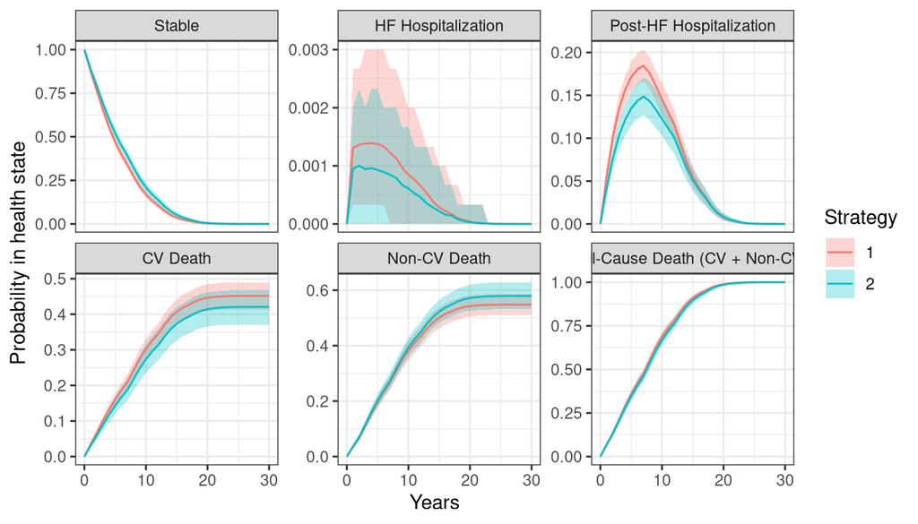

### 5.3.3 Costs and QALYs

Discount both costs and QALYs at *3% per year*, matching the study.

```r
econmod$sim_qalys(dr = .03)
econmod$sim_costs(dr = .03)
```

`$summarize()` aggregates mean costs and QALYs per PSA sample; `summary()` prints formatted results with strategy labels:

```r
ce_sim <- econmod$summarize()
summary(ce_sim, labels = hesim_labs) %>%
  format()
```

```
##    Discount rate        Outcome                        SOC
##            <num>         <fctr>                     <char>
## 1:          0.03          QALYs          5.16 (4.94, 5.37)
## 2:          0.03    Costs: Drug                   0 (0, 0)
## 3:          0.03 Costs: Medical 158,459 (151,162, 166,197)
## 4:          0.03  Costs: HFhosp      8,761 (6,853, 10,899)
## 5:          0.03   Costs: total 167,220 (159,257, 175,469)
##                        SGLT2i
##                        <char>
## 1:          5.34 (5.07, 5.61)
## 2:    24,828 (23,531, 26,046)
## 3: 162,848 (153,454, 172,115)
## 4:       6,113 (4,701, 7,872)
## 5: 193,790 (182,569, 204,612)
```

# 6 Decision analysis

Pairwise cost-effectiveness analysis versus SoC (strategy 1), with willingness-to-pay thresholds from $0 to $250,000 per QALY. The ICER table below is a compact summary; full outcome distributions appear in Table 2 and Figures 2A–2B.

```r
cea_pw_out <- cea_pw(ce_sim, comparator = 1, dr_qalys = 0.03, dr_costs = 0.03,
                     k = seq(0, 250000, 5000))
icer(cea_pw_out, labels = hesim_labs) %>%
  format(digits_qalys = 3)
```

```
##              Outcome                     SGLT2i
##               <fctr>                     <char>
## 1: Incremental QALYs      0.187 (-0.032, 0.403)
## 2: Incremental costs    26,569 (17,613, 34,547)
## 3:   Incremental NMB -17,197 (-20,560, -13,696)
## 4:              ICER                    141,741
```

# 7 Table 2. Cost-effectiveness outcomes: 2022-price validation anchor

This pooled SGLT2i run at the 2022 FSS price ($4,506) *validates* the model structure against Cohen et al. 2023; the forward-looking three-drug comparison at 2026 FSS prices is the headline (Figure 4).

Effectiveness is read off the simulated trajectories: HF hospitalizations are entries into state 2, person-years and mean survival come from each patient’s last exit time.

```r
dr <- 0.03
NP <- n_patients
NS <- n_samples
dpr <- econmod$disprog_          # reference (not copied) to limit memory

hf <- dpr[to == 2, .N, by = c("sample", "strategy_id")]
hf <- merge(CJ(sample = 1:NS, strategy_id = 1:2), hf,
            by = c("sample", "strategy_id"), all.x = TRUE)
hf[is.na(N), N := 0][, hf_count := N / NP]

py <- dpr[, .(surv = max(time_stop)), by = c("sample", "strategy_id", "patient_id")][
        , .(py = sum(surv), surv = mean(surv)), by = c("sample", "strategy_id")]
eff <- merge(hf, py, by = c("sample", "strategy_id"))
eff[, hf_rate := 100 * N / py]
```

Life-years are discounted time in the three living states, integrating `exp(-dr * t)` over every occupied interval rather than discounting at its midpoint.

```r
ly <- dpr[, .(ly = sum(ifelse(from %in% 1:3,
                              (exp(-dr*time_start) - exp(-dr*time_stop))/dr, 0)) / NP),
          by = c("sample", "strategy_id")]
eff <- merge(eff, ly, by = c("sample", "strategy_id"))
```

QALYs and costs come from `summarize()`; the outcome tables merge to one row per PSA sample and strategy.

```r
qal      <- ce_sim$qalys[dr == 0.03, .(qalys = qalys), by = c("sample", "strategy_id")]
cst_tot  <- ce_sim$costs[dr == 0.03 & category == "total", .(cost = costs), by = c("sample", "strategy_id")]
cst_drug <- ce_sim$costs[dr == 0.03 & category == "Drug",  .(drug = costs), by = c("sample", "strategy_id")]

M <- Reduce(function(a, b) merge(a, b, by = c("sample", "strategy_id")),
            list(eff[, .(sample, strategy_id, hf_count, hf_rate, surv, ly)], qal, cst_tot, cst_drug))
```

Putting the arms side by side within each sample gives the incremental differences, the ICER, and the share of samples in which SGLT2i is preferred at $150,000/QALY.

```r
soc <- M[strategy_id == 1]; sg <- M[strategy_id == 2]
W <- merge(soc, sg, by = "sample", suffixes = c("_soc", "_sg"))
W[, `:=`(d_qaly = qalys_sg - qalys_soc, d_cost = cost_sg - cost_soc,
         d_surv = surv_sg - surv_soc,   d_ly = ly_sg - ly_soc,
         d_hfc  = hf_count_sg - hf_count_soc, d_hfr = hf_rate_sg - hf_rate_soc,
         d_drug = drug_sg - drug_soc)]

icer_val <- mean(W$d_cost) / mean(W$d_qaly)
pref_sg  <- mean(150000 * W$d_qaly - W$d_cost > 0) * 100
```

The eight row labels, in the order the table presents them.

```r
outcomes <- c("Mean No. of HF hospitalizations",
              "HF hospitalization rate (per 100 person-years)",
              "Survival (undiscounted)", "Life-years (discounted)",
              "QALYs (discounted)",
              "Total lifetime costs", "SGLT2i costs",
              "Probability preferred at \\$150,000/QALY (%) or ICER (\\$/QALY gained)")
```

The two treatment columns. Effectiveness rows are formatted with `ui()` and cost rows with `uiM()`; the last row is a probability rather than an interval.

```r
col_soc <- c(ui(soc$hf_count), ui(soc$hf_rate), ui(soc$surv), ui(soc$ly), ui(soc$qalys),
             uiM(soc$cost), "NA", sprintf("%.1f%%", 100 - pref_sg))
col_sg  <- c(ui(sg$hf_count), ui(sg$hf_rate), ui(sg$surv), ui(sg$ly), ui(sg$qalys),
             uiM(sg$cost), uiM(sg$drug), sprintf("%.1f%%", pref_sg))
```

The incremental column holds SGLT2i minus SoC on every row except the last, which carries the ICER instead.

```r
col_inc <- c(ui(W$d_hfc), ui(W$d_hfr), ui(W$d_surv), ui(W$d_ly), ui(W$d_qaly),
             uiM(W$d_cost), uiM(W$d_drug),
             sprintf("$%s", format(round(icer_val), big.mark = ",")))
```

The published base case, transcribed from the paper’s Table 2. Each cell reads SoC / SGLT2i / incremental.

```r
col_pub <- c("0.74 / 0.53 / -0.22", "9.63 / 6.61 / -3.02",
             "7.73 / 7.95 / 0.22", "6.63 / 6.79 / 0.16", "5.27 / 5.46 / 0.19",
             "168,634 / 194,946 / 26,312", "NA / 24,920 / 24,920",
             "40.9% / 59.1% / 141,200")
```

The five columns assembled, in display order.

```r
table2 <- data.table(
  Outcome = outcomes,
  `SoC therapy` = col_soc,
  `SoC plus SGLT2i therapy` = col_sg,
  `Incremental value` = col_inc,
  `Cohen 2023 (2022 prices)` = col_pub)
```

Table 2. Cost-effectiveness outcomes: pooled SGLT2i base case at the 2022 FSS price ($4,506), the 2022-price validation anchor (mean and 95% UI from 1,000 PSA iterations). Final column is the Cohen et al. 2023 published base case at 2022 prices (SoC / SGLT2i / Incremental).

| Outcome | SoC therapy | SoC plus SGLT2i therapy | Incremental value | Cohen 2023 (2022 prices) |
| --- | --- | --- | --- | --- |
| **Effectiveness** |  |  |  |  |
| Mean No. of HF hospitalizations | 0.85 (0.65 to 1.06) | 0.59 (0.45 to 0.77) | -0.25 (-0.39 to -0.12) | 0.74 / 0.53 / -0.22 |
| HF hospitalization rate (per 100 person-years) | 10.93 (8.51 to 13.69) | 7.42 (5.71 to 9.52) | -3.51 (-5.17 to -1.94) | 9.63 / 6.61 / -3.02 |
| Survival (undiscounted) | 7.74 (7.38 to 8.12) | 7.97 (7.50 to 8.41) | 0.23 (-0.14 to 0.58) | 7.73 / 7.95 / 0.22 |
| Life-years (discounted) | 6.61 (6.34 to 6.89) | 6.78 (6.43 to 7.11) | 0.17 (-0.11 to 0.43) | 6.63 / 6.79 / 0.16 |
| QALYs (discounted) | 5.16 (4.94 to 5.37) | 5.34 (5.07 to 5.61) | 0.19 (-0.03 to 0.40) | 5.27 / 5.46 / 0.19 |
| **Direct medical costs (2022 $)** |  |  |  |  |
| Total lifetime costs | 167,220 (159,257 to 175,469) | 193,790 (182,569 to 204,612) | 26,569 (17,613 to 34,547) | 168,634 / 194,946 / 26,312 |
| SGLT2i costs | NA | 24,828 (23,531 to 26,046) | 24,828 (23,531 to 26,046) | NA / 24,920 / 24,920 |
| **Cost-effectiveness** |  |  |  |  |
| Probability preferred at $150,000/QALY (%) or ICER ($/QALY gained) | 44.1% | 55.9% | $141,741 | 40.9% / 59.1% / 141,200 |

# 8 Figure 1B. Projected cumulative all-cause mortality

Cumulative all-cause mortality is the probability of being in either death state (CV + non-CV) over time. Lines are PSA means; bands are 95% uncertainty intervals across the 1,000 iterations.

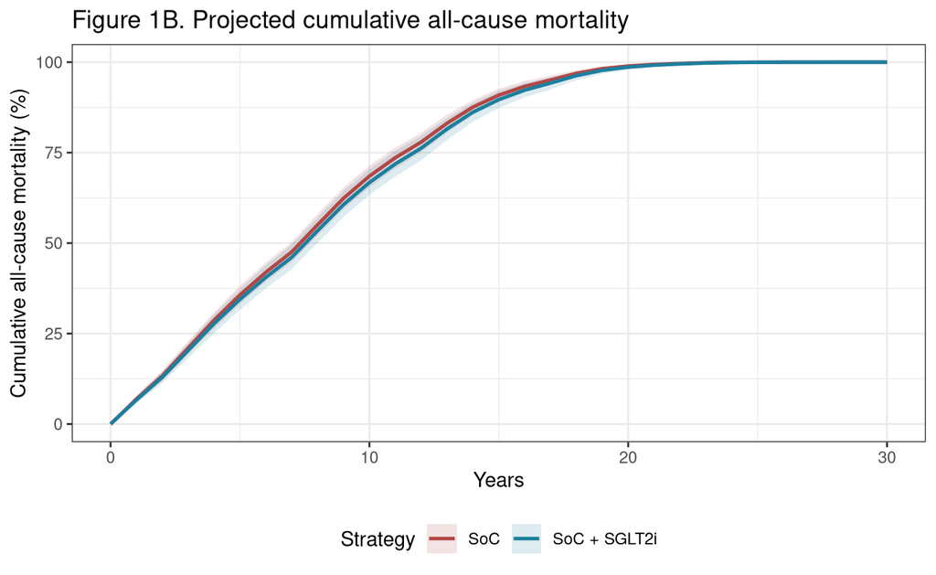

# 9 Figure 2. Cost-effectiveness of adding SGLT2i

*Panel A*: joint distribution of incremental cost and incremental QALYs across the 1,000 PSA iterations (red point = mean). Diagonal lines mark $50k and $150k per QALY.  
*Panel B*, cost-effectiveness acceptability curve: probability that SoC + SGLT2i is preferred at each willingness-to-pay threshold.

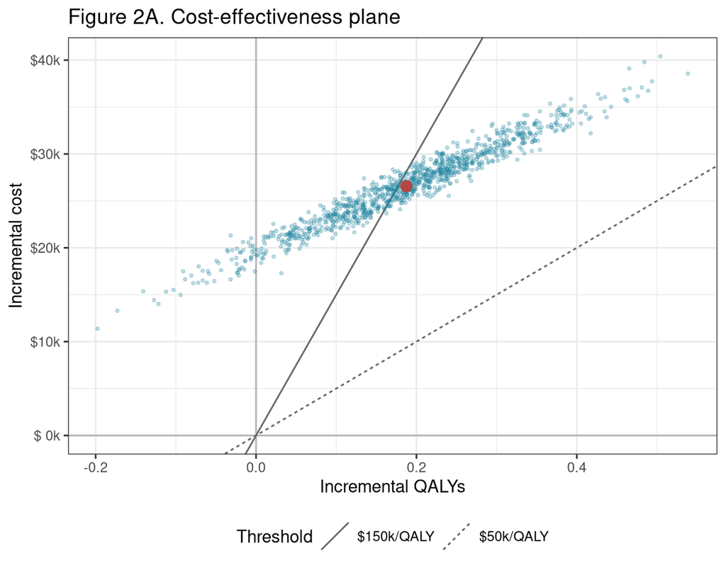

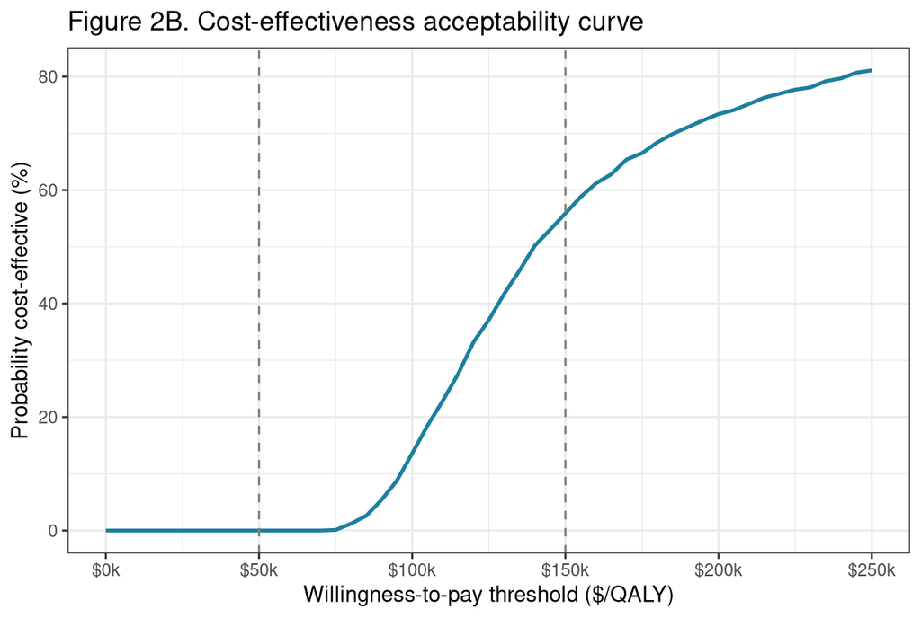

# 10 Figure 3. One-way sensitivity analyses (tornado)

Each input is set to its Table 1 low and high value in turn, everything else held at base case, and the resulting ICER recorded; the longer the bar, the more that input drives the result.

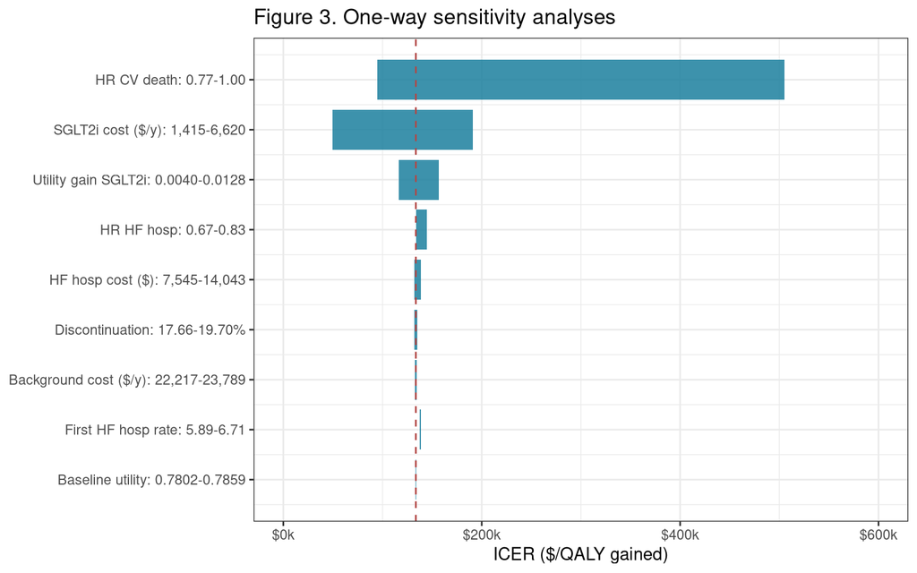

# 11 Supplement reproduction (eMethods 1–6)

Reproduced as far as individual simulation allows; 2022 USD throughout.

Differences: continuous-time vs cohort modelling (commonest), CDC WONDER mortality split, or eFigure 7’s reduced PSA.

## 11.1 eMethods 1: Pooled Trial Population

Inverse-variance-weighted EMPEROR-Preserved<sup>3</sup> and DELIVER<sup>4</sup> control arms: n = 12,251, age 71.7 y, 55.7% male; weighted means fixed.

eTable 5. Trial-specific model inputs (base case, sensitivity range).

| Parameter | EMPEROR-Preserved | DELIVER |
| --- | --- | --- |
| Rate of first HF hospitalization (/100 py) | 6.00 (5.41–6.66) | 6.50 (5.91–7.15) |
| Rate of HF urgent care visits (/100 py) | 3.50 (3.04–3.99) | 1.10 (0.87–1.36) |
| In-trial cardiovascular death (/100 py) | 3.30 (2.90–3.80) | 3.80 (3.40–4.30) |
| In-trial all-cause mortality (/100 py) | 6.70 (6.10–7.40) | 7.60 (7.00–8.30) |
| Probability of discontinuing SGLT2i (%) | 23.20 (21.71–24.73) | 14.18 (12.99–15.54) |
| HR for HF hospitalization vs SoC | 0.71 (0.60–0.83) | 0.77 (0.67–0.89) |
| HR for HF urgent care visit vs SoC | 0.61 (0.50–0.76) | 0.76 (0.55–1.07) |
| HR for cardiovascular death vs SoC | 0.88 (0.73–1.07) | 0.88 (0.74–1.05) |
| Annual drug cost, 2022 base case ($) | 4,193 (1,465–6,664) | 4,820 (1,366–6,576) |
| Annual drug cost, 2026 FSS Big-4 ($) | 3,761 (JARDIANCE, brand) | 5,340 brand (FARXIGA) / 2,898 generic |
| Baseline utility | 0.7892 (0.7864–0.7920) | 0.7772 (0.7744–0.7800) |

## 11.2 eMethods 2: Survival Projections

SoC mortality is flat in-trial (≤ 2.3 y), then the US age-specific rate times the paper’s ratio (3.54 all-cause, 4.73 CV). SGLT2i applies HR 0.88 to CV death for life<sup>5</sup> and RR 1.05 → 1.00 to non-CV death. *Reproduced*, including the steps 3–4 split.

### 11.2.1 eTable 6: In-trial model calibration performance (2.3 y)

eTable 6. In-trial (2.3 y) calibration: simulation vs. published validation targets. HF urgent-care-visit rows are omitted (that event type is not modelled here).

| Metric | Validation target (95% UI) | Simulation output (95% UI) |
| --- | --- | --- |
| **First HF Hospitalization** |  |  |
| First HF hospitalization rate (/100 py) |  |  |
| SoC | 6.3 (5.8–6.7) | 5.8 (5.2–6.5) |
| SoC + SGLT2i | 4.7 (4.3–5.0) | 4.4 (3.7–5.1) |
| Hazard ratio | 0.74 (0.67–0.83) | 0.76 (0.63–0.90) |
| **Cardiovascular Death** |  |  |
| Cardiovascular death rate (/100 py) |  |  |
| SoC | 3.6 (3.2–3.9) | 3.6 (3.0–4.1) |
| SoC + SGLT2i | 3.1 (2.8–3.4) | 3.2 (2.5–3.9) |
| Hazard ratio | 0.88 (0.77–1.00) | 0.89 (0.70–1.13) |
| **All-Cause Death** |  |  |
| All-cause death rate (/100 py) |  |  |
| SoC | 7.2 (6.7–7.6) | 7.2 (6.4–8.0) |
| SoC + SGLT2i | 6.9 (6.5–7.4) | 6.9 (6.1–7.8) |
| Hazard ratio | 0.97 (0.88–1.06) | 0.97 (0.84–1.12) |

### 11.2.2 eFigure 2: Survival model and extrapolation beyond trial duration

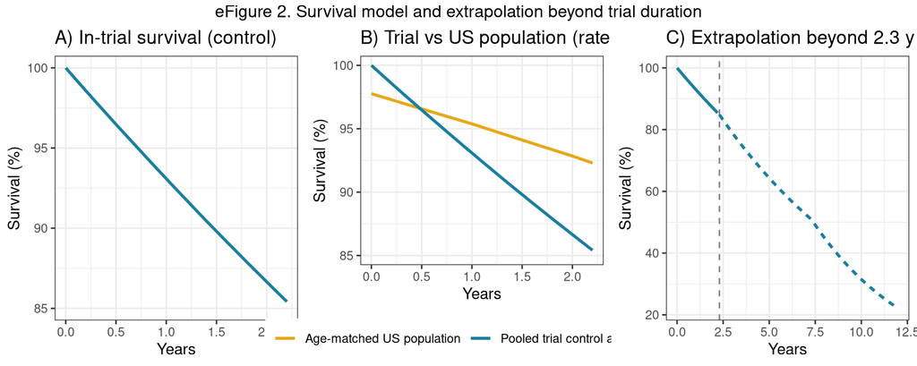

### 11.2.3 eFigure 3: Lifetime HF hospitalizations and mortality projections

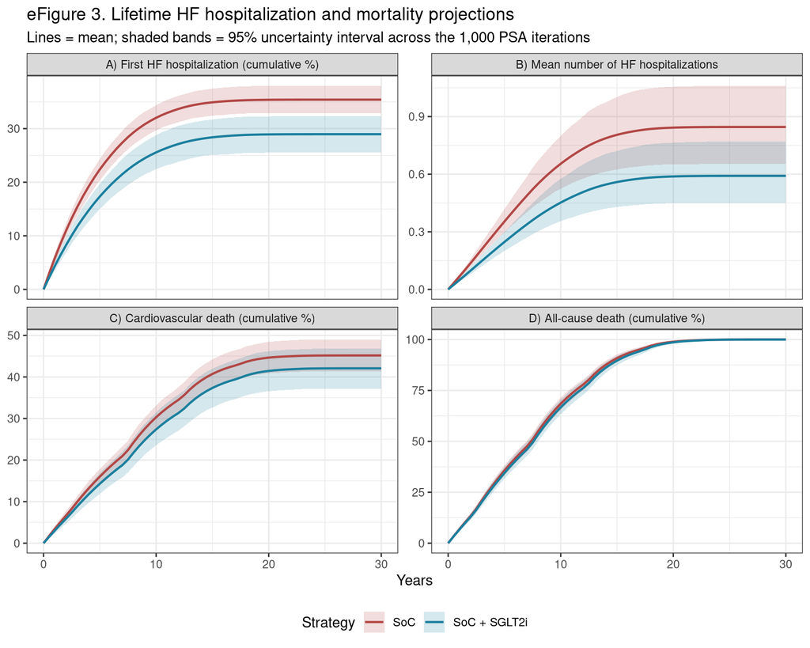

## 11.3 eMethods 3: Risk of Hospital Readmissions

Readmission risk is highest in the first 30 days and decays thereafter, implemented as the transition-7 piecewise-exponential schedule, relative risks 1.00 → 0.34 → 0.21 → 0.18 on the 30-day HF-readmission rate. *Partially reproduced:* the supplement returns risk to its pre-hospitalization level from 24 months, but this model has no 24-month knot and holds the final 0.18 for life, leaving late readmission risk ~3.8× baseline in both arms, a plausible contributor to the incremental HF-hospitalization count overshooting the published −0.22.

## 11.4 eMethods 4: Quality of Life

KCCQ-OSS is mapped to EQ-5D utility by published regression (baseline 0.783; SGLT2i benefit +0.0084, persisting for life). *Reproduced:* the three supplement scenarios, MEPS baseline 0.708 with and without the trial benefit, and the benefit declining linearly to zero over the five years *after* trial completion (year 7.3), all run in *eTable 8*.

## 11.5 Sensitivity and scenario analyses (eTable 4 definitions; eTables 7–9; eFigures 4, 6, 8, 9)

### 11.5.1 eTable 4: Sensitivity and scenario analysis (definitions)

eTable 4. Sensitivity and scenario analyses examined.

| Analysis | Change to model assumptions |
| --- | --- |
| One-way deterministic | Vary one parameter at its range; find thresholds for high/intermediate/low value |
| CV death × drug cost (two-way) | Vary CV-death HR and drug cost together; non-CV correlated so HR 1 = no mortality effect |
| Generic price × years to entry (two-way) | Simultaneously vary time to generic entry and % price reduction |
| Baseline age (60–80) | Update SoC first-HF-hosp, CV and all-cause rates by age; SGLT2i HRs unchanged |
| Baseline LVEF (40–49 / 50–59 / ≥60%) | Update SoC rates by LVEF group; SGLT2i HRs unchanged |
| Time horizon (0.5 y–lifetime) | Report outcomes at horizons from 6 months to lifetime (2.3 y = trial period) |
| Post-trial non-CV death persists | In-trial non-CV death RR 1.05 retained over the lifetime |
| Post-trial HRs wane to 0 by 5 y | HF-hosp, urgent-care and CV-death HRs decline linearly to no effect at 5 y |
| MEPS baseline QoL (0.708) + benefit | Baseline utility 0.708 from MEPS; keep trial QoL benefit |
| MEPS baseline QoL, no benefit | Baseline utility 0.708 from MEPS; no QoL benefit with SGLT2i |
| QoL benefit wanes by 5 y | QoL benefit declines linearly to zero difference by 5 y post-trial |
| EMPEROR-Preserved / DELIVER specific | Populate/calibrate model with each trial’s own inputs (eTable 5) |
| No SGLT2i effect on mortality (HRs = 1) | Set all mortality HRs to 1 (see eTable 9, eFigures 8–9) |

### 11.5.2 eFigure 4: Two-way: SGLT2i cost × cardiovascular-mortality HR

Annual SGLT2i cost and the CV-death hazard ratio are varied simultaneously. Colour saturates at $50,000 and $150,000. Because the ICER is affine in price at a fixed hazard ratio, the price axis is solved analytically from one simulation per hazard ratio rather than simulated at all 180 × 23 grid points.

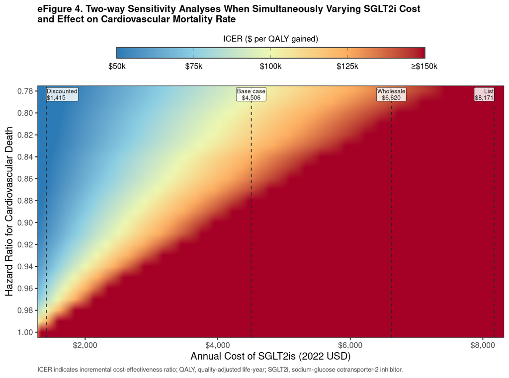

### 11.5.3 eTable 7: Two-way: years to generic entry × % price reduction

ICER is linear in discounted drug cost; cuts apply only after generic entry.

eTable 7. Approximate ICER by years to generic entry (columns) and % price reduction, base $4,506; ACC/AHA bands green <$50,000/QALY, yellow <$150,000.

|  | 1 | 2 | 3 | 4 | 5 | 6 | 7 | 8 | 9 | 10 |
| --- | --- | --- | --- | --- | --- | --- | --- | --- | --- | --- |
| 5% | $128,327 | $129,102 | $129,800 | $130,415 | $130,957 | $131,434 | $131,854 | $132,218 | $132,519 | $132,765 |
| 15% | $117,814 | $120,140 | $122,233 | $124,079 | $125,704 | $127,135 | $128,395 | $129,488 | $130,388 | $131,127 |
| 25% | $107,301 | $111,177 | $114,666 | $117,743 | $120,452 | $122,836 | $124,935 | $126,757 | $128,258 | $129,490 |
| 35% | $96,788 | $102,214 | $107,099 | $111,407 | $115,199 | $118,537 | $121,476 | $124,026 | $126,128 | $127,852 |
| 45% | $86,275 | $93,252 | $99,532 | $105,070 | $109,946 | $114,238 | $118,017 | $121,296 | $123,998 | $126,215 |
| 55% | $75,762 | $84,289 | $91,965 | $98,734 | $104,693 | $109,939 | $114,557 | $118,565 | $121,868 | $124,577 |
| 65% | $65,250 | $75,327 | $84,398 | $92,398 | $99,441 | $105,640 | $111,098 | $115,834 | $119,738 | $122,940 |
| 75% | $54,737 | $66,364 | $76,831 | $86,062 | $94,188 | $101,342 | $107,639 | $113,104 | $117,608 | $121,303 |
| 85% | $44,224 | $57,401 | $69,264 | $79,725 | $88,935 | $97,043 | $104,179 | $110,373 | $115,478 | $119,665 |
| 95% | $33,711 | $48,439 | $61,697 | $73,389 | $83,682 | $92,744 | $100,720 | $107,643 | $113,348 | $118,028 |

### 11.5.4 eFigure 6: Cost-effectiveness by time horizon

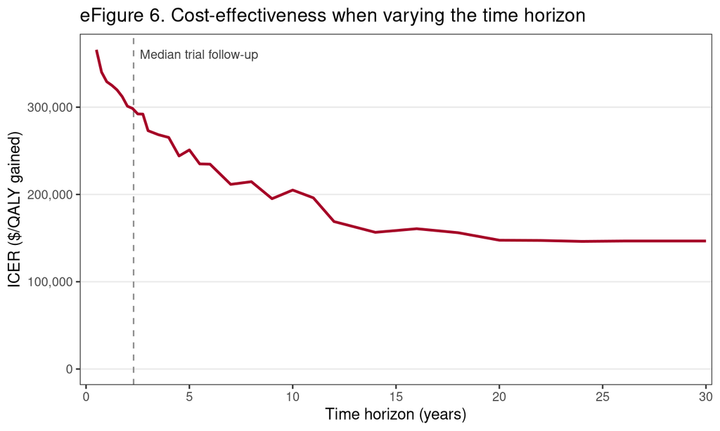

Waviness is Monte Carlo noise. The curve converges to $146,686/QALY, eTable 8’s base case; beyond 30 years every horizon returns that identical value; the published figure plots months instead of years and runs to 300.

### 11.5.5 eTable 8: Cost-effectiveness in additional sensitivity analyses

eTable 8. Cost-effectiveness in additional sensitivity and scenario analyses.

| Scenario | SoC cost | SGLT2i cost | Incr. cost | Incr. QALYs | ICER |
| --- | --- | --- | --- | --- | --- |
| Base case<sup>a</sup> | 167,322 | 193,631 | 26,308 | 0.18 | $146,686 |
| Post-trial non-CV death persists | 167,322 | 191,216 | 23,894 | 0.12 | $202,814 |
| Post-trial HRs wane to 0 by 5 y<sup>b</sup> | 167,081 | 192,618 | 25,537 | 0.13 | $196,254 |
| MEPS baseline QoL (0.708) + benefit | 167,322 | 193,631 | 26,308 | 0.17 | $156,979 |
| MEPS baseline QoL, no benefit | 167,322 | 193,631 | 26,308 | 0.11 | $237,750 |
| QoL benefit wanes by 5 y<sup>c</sup> | 167,322 | 193,631 | 26,308 | 0.16 | $168,925 |
| EMPEROR-Preserved specific<sup>d</sup> | 167,380 | 189,940 | 22,560 | 0.17 | $135,826 |
| DELIVER specific<sup>d</sup> | 167,643 | 197,861 | 30,218 | 0.19 | $158,736 |

Notes:  
Deterministic point estimates, 3,500 patients per scenario, 2022 USD.  
<sup>a</sup> $146,686/QALY point estimate; paper’s PSA-mean $141,200, its cohort ICERs ~$151,000-$223,000. Rows are directional shifts.  
<sup>b</sup> Paper: $221,400.  
<sup>c</sup> Paper: $163,500.  
<sup>d</sup> Empagliflozin $4,193, dapagliflozin $4,820 (eTable 5).

### 11.5.6 eFigure 7: Cost-effectiveness by trial population (PSA)

PSA per trial, each at *its own price* (eTable 8).

Departures: fewer draws than the paper; price log-SD halved.

*2022*-priced; Figure 4.

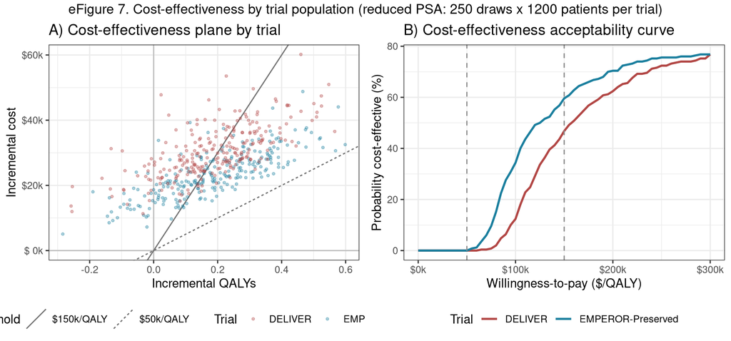

### 11.5.7 eTable 9: Cost-effectiveness assuming no effect of SGLT2i on mortality

eTable 9. No mortality effect (all mortality HRs = 1). ICER = $477,002/QALY. Paper: $373,400.

| Outcome | SoC | SoC + SGLT2i | Incremental |
| --- | --- | --- | --- |
| Mean # HF hospitalizations | 0.84 | 0.57 | -0.27 |
| Survival (undiscounted, y) | 7.75 | 7.73 | -0.02 |
| Discounted life-years | 6.62 | 6.61 | -0.02 |
| QALYs (discounted) | 5.16 | 5.21 | 0.04 |
| Total lifetime cost ($) | 167,322 | 188,315 | 20,992 |
| SGLT2i drug cost ($) | NA | 24,190 | 24,190 |

> *No-mortality scenario, post-Correction-1* (eMethods 2, step 5). Survival gain ≈ 0 y, leaving QoL and fewer hospitalizations; ICER unstable.

### 11.5.8 eTable 10: Additional sensitivity analyses assuming no effect on mortality

The no-mortality-effect assumption (all mortality HRs = 1, as in eTable 9) is now applied to the four eTable 8 scenario variants. With CV-death benefit removed, only the QoL differential and fewer HF hospitalizations remain, so every ICER is far above the $150k threshold (“low value”).

eTable 10. Paper, by row: $410,800; $374,600; $4,359,500; $649,000.

| Scenario | SoC cost | SGLT2i cost | Incr. cost | Incr. QALYs | ICER |
| --- | --- | --- | --- | --- | --- |
| Post-trial HRs wane to 0 by 5 y | 167,081 | 190,207 | 23,127 | 0.07 | $352,056 |
| MEPS baseline QoL (0.708) + benefit | 167,322 | 188,315 | 20,992 | 0.05 | $464,645 |
| MEPS baseline QoL, no benefit | 167,322 | 188,315 | 20,992 | -0.01 | dominated |
| QoL benefit wanes by 5 y | 167,322 | 188,315 | 20,992 | 0.02 | $973,658 |

### 11.5.9 eTable 11: Two-way (years to generic × % price reduction), no mortality effect

The eTable 7 grid, recomputed on the no-mortality-effect base case.

eTable 11. No-mortality base $361,207/QALY (paper ~$352,924 at 5%/1y).

|  | 1 | 2 | 3 | 4 | 5 | 6 | 7 | 8 | 9 | 10 |
| --- | --- | --- | --- | --- | --- | --- | --- | --- | --- | --- |
| 5% | $343,793 | $346,451 | $348,843 | $350,942 | $352,775 | $354,377 | $355,763 | $356,956 | $357,929 | $358,719 |
| 15% | $308,965 | $316,939 | $324,117 | $330,412 | $335,913 | $340,718 | $344,877 | $348,455 | $351,375 | $353,745 |
| 25% | $274,137 | $287,428 | $299,391 | $309,882 | $319,050 | $327,058 | $333,991 | $339,954 | $344,820 | $348,771 |
| 35% | $239,309 | $257,916 | $274,664 | $289,352 | $302,188 | $313,399 | $323,104 | $331,452 | $338,265 | $343,796 |
| 45% | $204,482 | $228,405 | $249,938 | $268,822 | $285,325 | $299,740 | $312,218 | $322,951 | $331,711 | $338,822 |
| 55% | $169,654 | $198,893 | $225,211 | $248,292 | $268,463 | $286,081 | $301,331 | $314,450 | $325,156 | $333,847 |
| 65% | $134,826 | $169,382 | $200,485 | $227,762 | $251,600 | $272,421 | $290,445 | $305,949 | $318,602 | $328,873 |
| 75% | $99,998 | $139,870 | $175,759 | $207,232 | $234,737 | $258,762 | $279,558 | $297,447 | $312,047 | $323,899 |
| 85% | $65,170 | $110,359 | $151,032 | $186,701 | $217,875 | $245,103 | $268,672 | $288,946 | $305,492 | $318,924 |
| 95% | $30,343 | $80,847 | $126,306 | $166,171 | $201,012 | $231,444 | $257,786 | $280,445 | $298,938 | $313,950 |

### 11.5.10 eFigure 8: Cost-effectiveness plane, no mortality effect

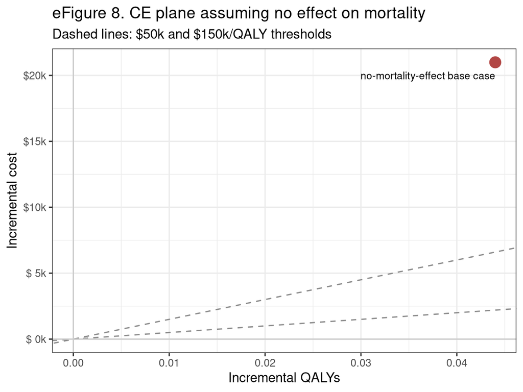

### 11.5.11 eFigure 9: One-way sensitivity, no mortality effect

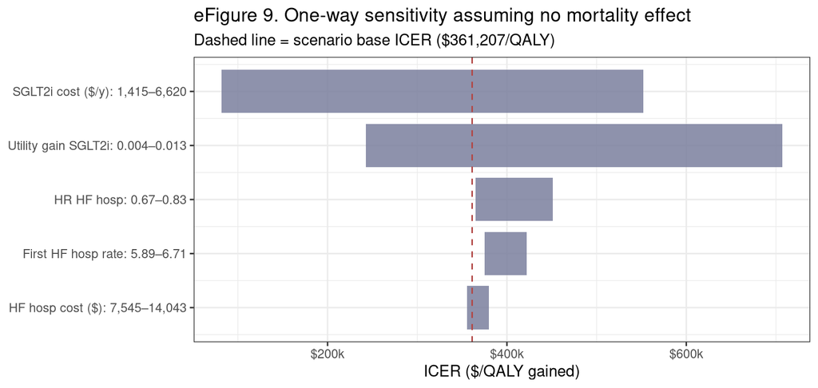

## 11.6 eMethods 5: Exploratory analyses varying baseline age and LVEF (eFigure 5)

*Not reproduced.* Age- and LVEF-banded SoC rates are not digitised.

## 11.7 eMethods 6: Annual effect on US healthcare spending (eFigure 10)

*Reproduced:* ≈ $3.9 B/y against the published $4.3 B.

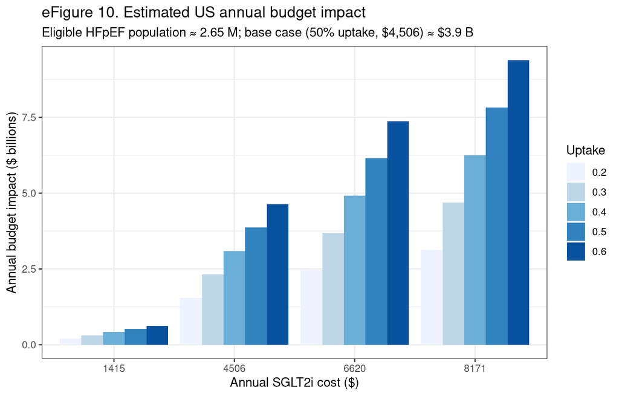

### 11.8.1 eTable 1: Key model assumptions

eTable 1. Key model assumptions (with notes on where this hesim adaptation differs from the original TreeAge model).

| Component | Assumption (this model) |
| --- | --- |
| Population | Pooled EMPEROR-Preserved + DELIVER; 71.7 y, 55.7% male |
| Time horizon / cycle / perspective | Lifetime; continuous time (paper: monthly); health-care sector |
| Model type | Individual-level state-transition (paper: TreeAge Markov cohort) |
| Cardiovascular mortality | Pooled control rate, then US rate × rate ratio; HR 0.88 lifetime |
| All-cause mortality | Calibrated in-trial; non-CV = all-cause − CV; no post-trial non-CV effect |
| First HF hospitalization | 6.26/100 py; HR 0.74 lifetime |
| Subsequent HF hospitalizations | Elevated to 12 mo, then held for life (paper: baseline at ≥24 mo) |
| HF urgent care visits | Not modelled (structural gap vs. paper) |
| Background medical costs | One age band, $23,004 (paper: three) |
| Medication costs | FSS Big-4 mean, 10 mg; $4,506/y |
| HF hospitalization/urgent-care costs | Facility (NIS) + professional fee; per admission |
| Quality of life | KCCQ→EQ-5D; benefit persists; first-year dynamics simplified |

### 11.8.2 eTable 2: Second Panel reporting checklist

Transcribed verbatim, not a model output; *Second Panel* checklist,<sup>26</sup> not CHEERS.

eTable 2. Reporting checklist for cost-effectiveness analyses from the Second Panel on Cost-Effectiveness in Health and Medicine (transcribed from the published supplement; ✓ = element documented).

| Element | Manuscript | Supplement |
| --- | --- | --- |
| **Introduction** |  |  |
| Background of the problem | ✓ |  |
| **Study Design and Scope** |  |  |
| Objectives | ✓ |  |
| Audience | ✓ |  |
| Type of analysis | ✓ |  |
| Target populations | ✓ |  |
| Description of interventions and comparators (incl. no intervention) | ✓ |  |
| Other intervention descriptors (care setting, delivery, intensity, timing) | ✓ |  |
| Boundaries of the analysis (scope / comprehensiveness of study) | ✓ |  |
| Time horizon | ✓ |  |
| Analytic perspectives (health care sector, societal, payer) | ✓ |  |
| Whether analysis meets the requirements of the reference case |  | ✓ |
| Analysis plan | ✓ |  |
| **Methods and Data** |  |  |
| Description of event pathway or model (states included) | ✓ |  |
| Diagram of event pathway or model (sequencing / transitions) |  | ✓ |
| Description of model used (e.g., state transition, microsimulation) | ✓ |  |
| Modeling assumptions | ✓ | ✓ |
| Software used | ✓ |  |
| Identification of key outcomes | ✓ |  |
| Complete information on sources of effectiveness, cost, preference data | ✓ | ✓ |
| Methods for obtaining estimates of effectiveness (evidence synthesis) | ✓ | ✓ |
| Methods for obtaining estimates of costs and preference weights | ✓ |  |
| Critique of data quality |  |  |
| Statement of costing year | ✓ |  |
| Statement of method used to adjust costs for inflation | ✓ |  |
| Statement of type of currency | ✓ |  |
| Source/methods for expert judgment (if applicable) | N/A |  |
| Statement of discount rates | ✓ |  |
| **Impact Inventory** |  |  |
| Full accounting of consequences within and outside the health care sector |  | ✓ |
| **Results** |  |  |
| Results of model validation | ✓ | ✓ |
| Reference case results (discounted & undiscounted; total & incremental; ICERs; uncertainty) | ✓ |  |
| Disaggregated results for important categories of costs/outcomes | ✓ |  |
| Results of sensitivity analysis | ✓ | ✓ |
| Other estimates of uncertainty | ✓ |  |
| Graphical representation of cost-effectiveness results | ✓ | ✓ |
| Graphical representation of uncertainty analyses | ✓ | ✓ |
| Aggregate cost and effectiveness information | ✓ | ✓ |
| Secondary analyses | ✓ | ✓ |
| **Disclosures** |  |  |
| Statement of potential conflicts of interest | ✓ |  |
| **Discussion** |  |  |
| Summary of reference case results | ✓ |  |
| Summary of sensitivity of results to assumptions/uncertainties | ✓ |  |
| Discussion of results in context of related cost-effectiveness analyses | ✓ |  |
| Discussion of ethical implications (distributive implications) | ✓ |  |
| Limitations of the study | ✓ |  |
| Relevance of results to specific policy questions or decisions | ✓ |  |

### 11.8.3 eTable 3: Formal health care sector impact inventory assessment

eTable 3. Formal health care sector impact inventory assessment (transcribed from the published supplement).

| Type of impact | Accounted for in analysis |
| --- | --- |
| **Health outcomes (effects)** |  |
| Longevity | ✓ |
| Health-related quality-of-life effects | ✓ |
| Other health effects (e.g., adverse events) | ✓ |
| **Medical costs** |  |
| Paid for by third-party payers | ✓ |
| Paid for by patients out-of-pocket | ✓ |
| Future related medical costs (payers and patients) | ✓ |
| Future unrelated medical costs (payers and patients) | ✓ |

# 12 References

Except where noted, model inputs are those reported by Cohen et al.;<sup>2</sup> the citation given is the source *they* used, and the access dates are theirs.

1.

Incerti D, Jansen JP. hesim: Health Economic Simulation Modeling and Decision Analysis. *arXiv*. 2021;2102.09437. https://arxiv.org/abs/2102.09437

2.

Cohen LP, Isaza N, Hernandez I, et al. Cost-effectiveness of sodium-glucose cotransporter-2 inhibitors for the treatment of heart failure with preserved ejection fraction. *JAMA Cardiol*. 2023;8(5):419-428. doi:10.1001/jamacardio.2023.0077

3.

Anker SD, Butler J, Filippatos G, et al. Empagliflozin in heart failure with a preserved ejection fraction. *N Engl J Med*. 2021;385(16):1451-1461. doi:10.1056/NEJMoa2107038

4.

Solomon SD, McMurray JJV, Claggett B, et al. Dapagliflozin in heart failure with mildly reduced or preserved ejection fraction. *N Engl J Med*. 2022;387(12):1089-1098. doi:10.1056/NEJMoa2206286

5.

Vaduganathan M, Docherty KF, Claggett BL, et al. SGLT-2 inhibitors in patients with heart failure: A comprehensive meta-analysis of 5 randomized controlled trials. *Lancet*. 2022;400(10354):757-767. doi:10.1016/S0140-6736(22)01429-5

6.

Cheng RK, Cox M, Neely ML, et al. Outcomes in patients with heart failure with preserved, borderline, and reduced ejection fraction in the Medicare population. *Am Heart J*. 2014;168(5):721-730. doi:10.1016/j.ahj.2014.07.008

7.

Arora S, Lahewala S, Hassan Virk HU, et al. Etiologies, trends, and predictors of 30-day readmissions in patients with diastolic heart failure. *Am J Cardiol*. 2017;120(4):616-624. doi:10.1016/j.amjcard.2017.05.028

8.

Goyal P, Loop M, Chen L, et al. Causes and temporal patterns of 30-day readmission among older adults hospitalized with heart failure with preserved or reduced ejection fraction. *J Am Heart Assoc*. 2018;7(9):e007785. doi:10.1161/JAHA.117.007785

9.

Chamberlain AM, Dunlay SM, Gerber Y, et al. Burden and timing of hospitalizations in heart failure: A community study. *Mayo Clin Proc*. 2017;92(2):184-192. doi:10.1016/j.mayocp.2016.11.009

10.

Shah KS, Xu H, Matsouaka RA, et al. Heart failure with preserved, borderline, and reduced ejection fraction: 5-year outcomes. *J Am Coll Cardiol*. 2017;70(20):2476-2486. doi:10.1016/j.jacc.2017.08.074

11.

Arias E, Xu J. US life tables, 2018. *Natl Vital Stat Rep*. 2020;69(12):1-45.

12.

US Centers for Disease Control and Prevention. CDC WONDER. 2021. Accessed September 18, 2021. https://wonder.cdc.gov

13.

US Department of Veterans Affairs. VA federal supply schedule service. 2022. Accessed January 28, 2022. https://www.fss.va.gov/

14.

US Department of Veterans Affairs, Office of Procurement, Acquisition and Logistics, National Acquisition Center. Pharmaceutical pricing data as of March 1, 2026: Federal Supply Schedule and National Contracts prices for all National Acquisition Center programs. 2026. Accessed July 29, 2026. https://department.va.gov/procurement-acquisition-and-logistics/wp-content/uploads/sites/56/2026/03/TPharmPrices2026-03-01.xlsx

15.

Isaza N, Calvachi P, Raber I, et al. Cost-effectiveness of dapagliflozin for the treatment of heart failure with reduced ejection fraction. *JAMA Netw Open*. 2021;4(7):e2114501. doi:10.1001/jamanetworkopen.2021.14501

16.

HCUPnet. Healthcare cost and utilization project (HCUP): Introduction to the HCUP Nationwide Inpatient Sample (NIS) 2018. 2020. Accessed September 10, 2021. https://www.hcup-us.ahrq.gov/db/nation/nis/NISIntroduction2018.pdf

17.

Packer M, Butler J, Zannad F, et al. Effect of empagliflozin on worsening heart failure events in patients with heart failure and preserved ejection fraction: EMPEROR-Preserved trial. *Circulation*. 2021;144(16):1284-1294. doi:10.1161/CIRCULATIONAHA.121.056824

18.

Goyal P, Almarzooq ZI, Horn EM, et al. Characteristics of hospitalizations for heart failure with preserved ejection fraction. *Am J Med*. 2016;129(6):635.e15-635.e26. doi:10.1016/j.amjmed.2016.02.007

19.

Bryant KB, Moran AE, Kazi DS, et al. Cost-effectiveness of hypertension treatment by pharmacists in Black barbershops. *Circulation*. 2021;143(24):2384-2394. doi:10.1161/CIRCULATIONAHA.120.051683

20.

Kazi DS, Bellows BK, Baron SJ, et al. Cost-effectiveness of tafamidis therapy for transthyretin amyloid cardiomyopathy. *Circulation*. 2020;141(15):1214-1224. doi:10.1161/CIRCULATIONAHA.119.045093

21.

Peterson C, Xu L, Florence C, Grosse SD, Annest JL. Professional fee ratios for US hospital discharge data. *Med Care*. 2015;53(10):840-849. doi:10.1097/MLR.0000000000000410

22.

Butler J, Filippatos G, Jamal Siddiqi T, et al. Empagliflozin, health status, and quality of life in patients with heart failure and preserved ejection fraction: The EMPEROR-Preserved trial. *Circulation*. 2022;145(3):184-193. doi:10.1161/CIRCULATIONAHA.121.057812

23.

Thomas M, Jones PG, Cohen DJ, et al. Predicting the EQ-5D utilities from the Kansas City Cardiomyopathy Questionnaire in patients with heart failure. *Eur Heart J Qual Care Clin Outcomes*. 2021;7(4):388-396. doi:10.1093/ehjqcco/qcab014

24.

Sullivan PW, Ghushchyan V. Preference-based EQ-5D index scores for chronic conditions in the US. *Med Decis Making*. 2006;26(4):410-420. doi:10.1177/0272989X06290495

25.

Jaagosild P, Dawson NV, Thomas C, et al. Outcomes of acute exacerbation of severe congestive heart failure: Quality of life, resource use, and survival. *Arch Intern Med*. 1998;158(10):1081-1089. doi:10.1001/archinte.158.10.1081

26.

Sanders GD, Neumann PJ, Basu A, et al. Recommendations for conduct, methodological practices, and reporting of cost-effectiveness analyses: Second panel on cost-effectiveness in health and medicine. *JAMA*. 2016;316(10):1093-1103. doi:10.1001/jama.2016.12195

27.

Rane A, Nechi RN, Imam M, et al. Comparative value of dapagliflozin vs empagliflozin in patients with heart failure and preserved ejection fraction: A cost-effectiveness analysis. *J Manag Care Spec Pharm*. 2023;29(9):1045-1053. doi:10.18553/jmcp.2023.29.9.1045

28.

Ferreira JP, Zannad F, Butler J, et al. Genitourinary tract infections and SGLT2 inhibitors in heart failure: An EMPEROR-Pooled analysis. *Eur J Heart Fail*. Published online 2026:xuag054. doi:10.1093/ejhf/xuag054